# Statisztika II. - Python Alapok

Kovács László

2024.01.27.

## Előhang

Ez a jegyzet hivatalosan a Budapesti Corvinus Egyetem gazdaságinformatikus hallgatóinak készült abból a célból, hogy a Statisztika II. tárgy sikeres abszolválásához szükséges Python programnyelvi elemek felelevenítésre kerüljenek.

Viszont, a jegyzet előkészítése során arra jutottam, hogy egy kicsit általánosabb célú anyagot szeretnék készíteni: egy **olyan bevezető jegyzetet a Python nyelvhez**, ami kimondottan a **statisztikai és adatelemzési feladatok elvégzéséhez szükséges elemeit és kiegészítő csomagjait mutatja be** teljesen kezdő szinten, minden **programozási előismeret feltételezése nélkül**.

Ebből adódóan szeretném kicsit tételesen összefoglalni, hogy mire számíthat az olvasó a jegyzetben. Nem szeretek zsákba macskát árulni, így szeretném már előre letisztázni, hogy ez az anyag mivel foglalkozik a Python nyelven belül, és ami talán még fontosabb, hogy mivel *nem*.

A jegyzet **bemutatja**:

- A Python nyelv legalapvetőbb utasításait és elemeit.
- A Python nyelv statisztikai-adatelemzési feladatok megoldására könnyen használható adatszerkezeteit (`numpy` és `pandas` csomagok).
- A Python nyelv legalapvetőbb adatvizualizációs képességeit a `matplotlib` csomagon keresztül.
- Egy egyszerűbb, leíró statisztikai és *nem* modellezési célú adatelemzési folyamatban felmerülő leggyakoribb adatminőségi problémák azonosítási és megoldási módjait Python nyelven
- A *Spyder* fejlesztőkörnyezet működését és lehetőségeit adatelemzési feladatok megoldása során.

A jegyzetnek **nem célja**:

- Teljes körű áttekintést adni a Python nyelv elemeiről és adatszerkezeteiről. A Pythont végig csak *szkriptnyelvként* használjuk, nem pedig általános célú programnyelvként.
- A Python minden lehetséges fejlesztőkörnyeztetét (Jupyter Notebook, Visual Studio Code, replit.com, stb.) bemutatni.
- A `numpy`, `pandas` és `matplotlib` csomagok teljeskörű működéséről. Csak az alapvető leíró statisztikai és adatkezelési funkciókat tekintjük át.
- Teljes körű bemutatót adni a Python képességeiről az adatminőségi kihívások azonosítsa és kezelése területén. Tényleg csak a legalapvetőbb és leggyakrabban előforduló problémákat tekintjük át, a legegyszerűbb kezelési módokkal.
- A Python képességeinek áttekintése a következtető statisztika és a statisztikai modellezés vagy éppen gépi tanulás területén (`statmodels`, `sklearn`, `tensorflow`, stb. csomagok)

Ezen kívül a jegyzet **feltételez némi leíró statisztikai előismeretet**. Konkrétan a következő fogalmak ismeretét veszem adottnak:

- ismérv és azok mérési skálái
- átlag, szórás
- medián és egyéb kvantilisek
- hisztogram, doboz ábra
- eloszlások alakja
- korreláció és pontdiagram

**Ha** egy lelkes **gazdaságinformatikus hallgató forgatja a jegyzetet**, aki a *Programozás alapjai* tárgyban a Python nyelv és a `pandas` data frame-k alapjait már tökéletesen elsajátította biztosan sok “uncsi” részt fog találni a jegyzetben. Számára **leginkább csak a 8-13. fejezetek gyors átprögetését ajánlom**, hogy a statisztikai számítások elvégzéséhez és a statisztikai adattáblák kezeléséhez szükséges Python megoldásokat felelevenítse.  
Ugyanakkor fontos megjegyezenem, hogy a **Statisztika II. tárgy tanóráin a jelen jegyzetben szereplő tudást ismertnek feltételezzük, és nem fogunk rá külön kitérni az oktatás során!!** Szóval, ha valaki **egy kicsit is bizonytalan a Python ismereteiben, azért olvassa át ezt az ismétlő jegyzetet, és ha bármi nem világos, KÉRDEZZEN!!**

## 1. Programozási alapelvek

Mivel a Python egy programnyelv, így elengedhetetlen, hogy a használata előtt némi programozási alapvetésekkel tisztában legyünk.

Talán az már kijelenthetó, hogy közismert a tény, mi szerint a mai számítógépek alapvetően a Neumann-elvek szerint működnek.

A mi szempontunkból ez csak annyit jelent, hogy a számítógépet alapvetően *utasítások* végrehajtására használjuk programozás során: pl. számold ki ezt, vagy rajzold ki amazt. A programozás kihívása, hogy a gépállat felfogása nagyon nehéz, ezért az utasításokat nagyon konkrétan meg kell neki fogalmazni. Ehhez a megfogalmazáshoz adnak segítséget a különböző programnyelvek, így a Python is.

A Neumann-elvek szerint a programnyelven kiadott utasításokat a számítógépben a *processzor* (Central Processing Unit, CPU) hajtja végre. Ugyanakkor az utasítások végrehajtásához a gépnek adatokat is fejben kellhet tartania (mondjuk átlag számítás során nem árt tudnia milyen számok átlagát számoljuk ki). Ezeket az adatokat nem meglepő módon a *memóriájában* (Random Access Memory, RAM) tárolja a gép. A gépállattal való kommunikációhoz szükségvan valami beviteli = input eszközre (billentyűzet, egér) és az utasítások eredményének megjelenítéséhez kell egy kimeneti = output eszköz (monitor) is.

És…ennyi! Alapvetően a modern számítógépek ennyi alkotóelemből állnak (a háttértár programozás szempontjából irreleváns). Mindez egy cuki ábrán (a processzor belső felépítése minket jelenleg nem érdekel):

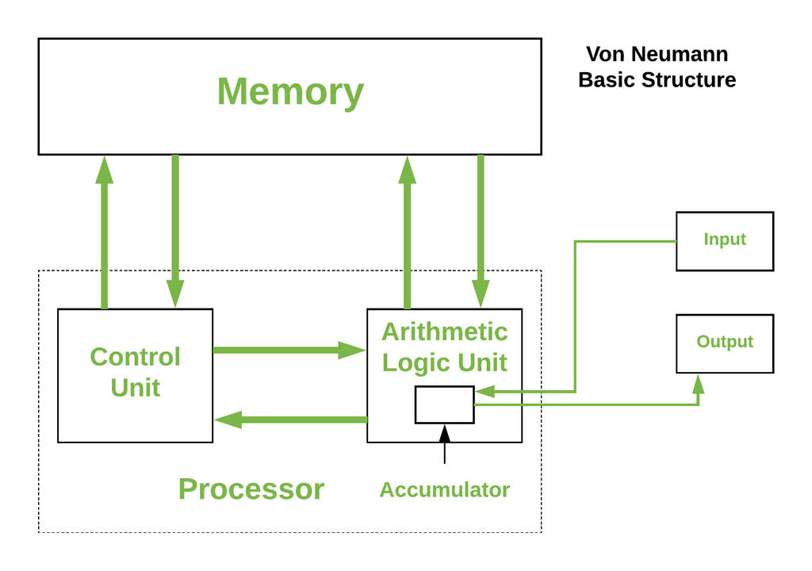

Számítógép vásárlás szempontjából is alapvetően a CPU és a RAM határozza meg mennyire gyors a gép: minél nagyobb a CPU órajele (GHz) és minél több magja van, annál több utasítást tud végrehajtani a gép egy adott idő alatt, és minél nagyobb a RAM mérete (GB) annál több adatot tud egyszerre fejben tartani. Talán nem ér minket meglepetésként, ha azt mondom, hogy a *statisztikai számítások alapvetően RAM igényesek* (mert sok adattal dolgoznak). 16-32 GB már kell, hogy komolyabb statisztikai modelleket gyorsan tudjunk futtatni egy valós vállalati adattáblán (ami általában több, mint 1 millió rekroddal és minimum 30-40 oszloppal = változóval rendelkezik).

## 2. A Pythonról általában

Az Python a jegyzet írásakor a legnépszerűbb általános célú programozási nyelv, 2024 januárjában a [TIOBE index](https://www.tiobe.com/tiobe-index/) alapján a legtöbb sor programkódot Python nyelven írják a fejlesztők.

A mi szempontunkból a Python olyan szempontból vonzó, hogy a külső kiegészítő csomagjai segítségével a valószínűségszámítás, statisztika és általánosabb adatelemzés műveletei könnyen és gyorsan elvégezhetők a segítségével. Tehát a Python használható olyan matematikai, statisztikai modellezési és elemzési feladatok elvégzésére alkalmas szkriptnyelvként, mint például az [R](https://cran.r-project.org/) vagy a [Matlab](https://www.mathworks.com/products/matlab.html). A Python előnye ezekkel a nyelvekkel szemben, hogy mivel általános célú programnyelv, így a matematikai-statisztikai számítások eredményei sokkal könnyebben integrálhatók egy üzleti célú alkalmazásba, ami mondjuk felhasználói felülettel rendelkezik.  
Ahogy az *Előhang*ban már jeleztem, a jegyzet kimondottan a Python statisztikai és adatelemzési funkcióinak alapszintű bemutatásával foglalkozik. Tehát alkalmazást fejleszteni itt nem fogunk, a Pythont szkriptnyelvként működtetjük: elküldjük a programkódban megírt számítási igényeinket a gépállatnak, és az visszaköpi a számítások eredményeit a képernyőre, és mi egyrészt gyönyörködünk bennük, másrészt értelmezzük az eredményeket. Viszont, jó tudni, hogy a Python az eredmények további felhasználására is képes programnyelv. Ebben több, mint egy matematikusi körökben szintén népszerű R vagy Matlab. Hátránya a felsorolt nyelvekkel szemben, hogy mivel általános célú programnyelv, és nem kimondottan a matematikai-statisztikai számításokra optimalizált, így számos számítás lekódolása sokkal körülményesebb Pythonban, mint R-ben vagy Matlabban. De hát *valamit valamiért*. :)

A Pythont, mi az **Anaconda keretrendszer**ből működtetjük, ami [innen letölthető](https://www.anaconda.com/products/distribution). Az Anaconda számos fejlesztőkörnyezetet biztosít a Python nyelvhez. Itt megjegyzendő, hogy a **Python és a Python fejlesztőkörnyezete nem összekeverendő!** A Python maga a programnyelv, amiben kódot írunk a számítógépünknek, hogy hajtsa végre, míg a fejlesztőkrönyezet az a program, amiben ezt a kódot megírjuk!  
Mi a Python kódjainkat **Spyder fejlesztőkörnyezetben** írjuk majd, mivel ez a fejlesztőkörnyezet az, ami leginkább a Python matematikai-statisztikai műveleteket végrehajtó, szkriptnyelv-szerű használatára van optimalizálva.

Miután telepítettük és elindítottuk az Anaconda keretrendszert, a kezdőképernyőről rögtön indíthatjuk is a Spydert:

[figure not shown]

## 3. A Spyder felülete

A Spyder fejlesztőkörnyezet indítása után az alábbihoz hasonló képernyőkép fogad minket:

[figure not shown]

A Python kódokat a Spyder-ben *.py* kiterjesztésű szkriptfájokban fogjuk írni.  
Egy ilyet az alább látható módon lehet létrehozni:

[video not shown]

A szkriptfájlba írhatjuk a gépállatnak szóló utasításainkat Python nyelven. Az utasítások végrehajtását a Spyder felület felső részén lakó gomb megtaposásával tudjuk kérni a géptől, aki az utasítás eredményét alul, a *Console* felületen köpi ki. Ekkor a Spyder mindig azt a Python utasítást hajtja végre a gomb megnyomásakor, amiben éppen a villogó kurzorral álltunk. Egy példában számoltassuk ki a Pythonnal, hogy mennyi $3+2$:

[video not shown]

Több utasítást is végre tudunk hajtatni a géppel egyszerre. Csak jelöljük ki a szkriptben a végrehajtandó utasításokat, és így kijelölés után tapossuk meg a Spyíder felső menüsorában található gombot! Egy utasítást több sorba is írhatunk, de egy új utasítás mindig új sorban kezdődjön! Érdemes egy üres sort is hagyni az előző utasítás vége után!

Számoltassunk akkor most ki a Pythonnal egyszerre két dolgot is: mennyi $3+2$ és mennyi $3 \times 2$:

[video not shown]

Ezek után a jegyezetek további részében a feladatok elvégzéséhez szükséges Python kódrészleteket és azok eredményét az alábbi módon jelölöm:

```python
3+2
```

```
## 5
```

```python
3*2
```

```
## 6
```

Ha az összes *.py* fájlukban lévő kódot le szeretnénk futtatni abban a sorrendben, ahogy a fájlban szerepelnek, akkor a Spyder felső menüsorán a gombot kell megütni. De vigyázzunk, ilyenkor a Python nem írja ki az utasításaink eredményét a konzolra, csak akkor, ha külön beágyazzuk őket egy `print` nevű extra utasítás zárójelei közé!

```python
print(3+2)
```

```
## 5
```

```python
print(3*2)
```

```
## 6
```

A művelet videón:

[video not shown]

## 4. Working Directory

Mielőtt belevágunk a Python mélyebb rejtelmeibe van még egy fontos dolog, amiről még szót kell ejteni: a *Working Directory* kérdéséről. A *Working Directory* az a mappa, ahonnan a *pitonállat* alapértelmezés szerint minden fájlt innen akar a memóriába tölteni és ide akar visszaírni. A Spyder jobb felső sarkában lévő részen lehet kiválasztani és beállítani, hogy melyik mappa legyen a *Working Directory*. Ezek után **minden fájlunk alapból ide fog mentődni, és minden adattáblát ide rakjunk be, amivel majd a Pythonban dolgozni akarunk!**

A Spyder-ben alapértelmezett *Working Directory*-t is be tudunk állítani, ha elbandukolunk a **Tools –> Preferences –> Current working directory** menübe, és ott a **Console directory / The following directory** című résznél beállítjuk a kívánt fix mappát alapértelmezett *Working Directory*-nak.

Az egész alapértelmezett *Working Directory*-val kapcsolatos okfejtés működésben megnézhető a következő videón:

[video not shown]

## 5. Alapvető Python adattípusok és adatszerkezetek

Eddig a Pythonban csak utasításokat hajtattunk végre, de a memóriában (RAM-ban) nem tároltattunk el még vele semmit.  
Most itt az idő! Az utasítások eredményét a `=` szimbólummal tudjuk a memóriába valamilyen szimpatikus néven elmenteni.

### 5.1. Egyszerű adattípusok

Mentsük el a 3+2 eredményét egy `összeg` névre hallgató R objektumba: `összeg = 3+2`. Az utasítás végrehajtásának hatására az `összeg` objektum megjelenik az Spyder *jobb felső* sarkában lévő résznél, a *Variable Explorer* fülön. (A Python alapjáraton karakterkészletben elég bő, így simán tudunk ékezetes objektumneveket is adni. De néha én a biztonság kedvéért megmaradok az ékezet nélküli elnevezéseknél. Öreg vagyok már, na! :)). A Spyder képernyőnek ezen a *Variable Explorer* részén látjuk mindig azt, hogy éppen milyen Python objektumok élnek a RAM-ban:

[video not shown]

A Python memória-objektumoknak több fajtája van. A legegyszerűbbek azok, amik csak egy értéket tartalmaznak (mint nekünk az előbb az `osszeg`). Ezeket szokás **változó**nak is hívni. Én nem szeretem ezt az elnevezést, mert keverhető a statisztikai értelemben vett változóval, ami mindig egy statisztikai megfigyelést leíró tulajdonságot/ismérvet jelent (pl. munkavállaló jövdeleme). Ennek ellenére én is gyakran használom a Python memória objektumokra a változó elnevezést. :)

A Python objektumoknak mindig van **adattípusa** is, ami **leírja, hogy az adott objektumban számértékű, szöveges, dátum vagy valami egyéb jellegű adatot tárolunk-e**. Ez azért marha fontos, mert az adattípustól függ, hogy mennyi hely szükséges a RAM-ban az objektum tárolásához. Érzésre megmondható talán, hogy egy szöveges adat tárolására több hely kell, mint egy egész szám tárolásához.

Az adattípusokat Pythonban a `type` névre hallgató **beépített függvénnyel** lehet lekérdezni.

Ezen a ponton érdemes megemlékezni arról, hogy a Pythonban léteznek **függvényként működő beépített utasítások** is. Ezek az úgynevezett Python függvények olyan utasítások, amik a matekban megszokott $f(x)$ függvény alakot veszik fel.  
A függvény neve leírja, hogy a függvény milyen műveletet végeztet el a gépállattal, és a zárójelek között pedig megadjuk, hogy milyen bemeneti paramétereken (adatokon) kell elvégezni a kijelölt műveletet. Pl. ilyen függvény volt már a `print` is.

Gyakorlati példaként lássuk akkor **Python függvények**re a `type` működését:

```python
összeg = 3+2
type(összeg)
```

```
## <class 'int'>
```

Ez a `type` nevű jószág azt csiripeli nekünk, hogy ez az `összeg` című változó egy `int` adattípusú, azaz **egész szám**, leánykori angolos nevén `integer`. Tehát, ha egy Python objektum `int` adattípusú, akkor az azt jelenti, hogy ő bezony csak egész számokat tud elképzelni a világban, tört számokat nem tud tárolni.

Törtszámok tárolására vannak a `float` adattípusú objektumok.

```python
tört = 3/2
type(tört)
```

```
## <class 'float'>
```

A Statisztika II. tárgyban a kétféle számítpus közti különbségnek nem igazán lesz jelentősége, de ha igazi *big data*-val foglalkozik az ember, akkor a RAM takarékosság miatt számít, hogy valami csak egy egész számnyi, vagy egy törtszámnyi helyet foglal sok-sok tizedeshellyel!

Néhány egyéb fontosabb adattípus és megadási módjuk:

```python
szoveg = "Hello There!" # Figyeljünk rá, hogy szöveget a kódban csak idézőjelek közé rakjunk! Mint Excelben! :)
type(szoveg)
```

```
## <class 'str'>
```

```python
igazhamis = True
type(igazhamis) # a bool típusnak csak két értéke lehet: True vagy False
```

```
## <class 'bool'>
```

A fenti kódrészletben szereplő **#** jel a komment jele a Pythonban. A **#** mögötti részeket a gépállat nem fogja végrehajtani, olyan lesz neki, mintha ott sem lenne. Ezzel magunknak írhatunk a Python szkriptbe hasznos megjegyzéseket.

Az egyes adattípusok között tudunk konvertálni, ha van ennek van értelme. A konverzóra függvényeket tudunk használni, amik neve kivétel nélkül megegyezik azzal a kulcsszóval, amit a `type` függvény visszaad adattípusnak. Tehát a függvény, ami mondjuk az objektumot szöveggé, azaz stringgé konvertálja az `str` névre hallgat.

Tehát akkor számból tudunk szöveget csinálni:

```python
szam = 1992
type(szam)
```

```
## <class 'int'>
```

```python
nemszam = str(szam)
type(nemszam)
```

```
## <class 'str'>
```

```python
nemszam
```

```
## '1992'
```

Láthjatjuk, hogy amikor kiíratjuk a `nemszam` változót, akkor ott az $1992$ már aposztrófok között van, ami azt jelöli, hogy ez beza már szöveges, azaz *string* adat.

Olyan szövegből tudunk számot csinálni, aminek tartalma tényleg egy valid szám:

```python
szöveg = "1992"
type(szöveg)
```

```
## <class 'str'>
```

```python
nemszöveg = int(szöveg)
type(nemszöveg)
```

```
## <class 'int'>
```

Tizedestörtekkel vigyázzunk! A **Python angol lokalizációt feltételez mindig**, így tizedes pontot kell alkalmazni! A tizedes vesszővel írt számot nem fogja felismerni, és hisztis hibaüzenetet dob. :( A `nemjo` változó pedig nem jön létre a memóriában.

```python
nemjo = float("3,14")
```

```
## could not convert string to float: '3,14'
```

```python
nemjo
```

```
## name 'nemjo' is not defined
```

```python
type(nemjo)
```

```
## name 'nemjo' is not defined
```

De ha a törtszám tizedes ponttal adott a string változóban, akkor az minden további nélkül `float` adattípusra konvertálható.

```python
jo = float("3.14")
jo
```

```
## 3.14
```

```python
type(jo)
```

```
## <class 'float'>
```

Ha törtszámot (`float`) etetünk meg vacsorára az `int` függvénnyel, akkor annak az egészrészét veszi.

```python
fura = int(3.14)
fura
```

```
## 3
```

```python
type(fura)
```

```
## <class 'int'>
```

Pythonban a rosszul beállított adattípusokból születhet pár baleset. Íme a leggyakoribb példák.

A `+` két string között az összefűzést jelenti, így az alábbi kód tökéletesen működőképes.

```python
szoveg1 = "Hello"
szoveg2 = "There"

szoveg1+szoveg2
```

```
## 'HelloThere'
```

Viszont a string és integer összege nem értelmezhető, így hibaüzi lesz a vége…mily meglepő :)  
Ellenben a szorzatuk értelmes eredményt mutat: a stringet összefűzi annyiszor amennyi az integer típusú változó értéke!

```python
szoveg = "3"
szam = 4

szoveg+szam
```

```
## can only concatenate str (not "int") to str
```

```python
szoveg*szam
```

```
## '3333'
```

Érdemes megnézni mi történik, ha egy stringként tárolt egész számot és egy integerként tárolt egész számot úgy “adunk össze” és “szorzunk össze”, hogy előtte a stringet integerré, vagy floattá konvertáljuk.

```python
szoveg = "3"
szam = 4

int(szoveg)+szam
```

```
## 7
```

```python
int(szoveg)*szam
```

```
## 12
```

```python
float(szoveg)+szam
```

```
## 7.0
```

```python
float(szoveg)*szam
```

```
## 12.0
```

Ekkor igazából semmi galiba nem történik, minden szituáció értelmes eredményre vezet. Annyi, hogy amikor `float`-ra konvertáltuk a stringben tárolt egész számot, akkor az eredmény is `float` típusú objektum lesz. Ezt onnan látni a `type` függvény nélkül, hogy pl. a `float(szoveg)+szam` eredménye $7.0$ lesz a `int(szoveg)+szam`-féle $7$ helyett.

Viszont, ha a stringben egy tizedes törtet tárolok el (rendesen tizedes ponttal), akkor az már összeveszik az `int` függvénnyel, és ezekben a csillagálásokban hibát dob a pitonállat.

```python
szoveg = "3.5"
szam = 4

szoveg+szam
```

```
## can only concatenate str (not "int") to str
```

```python
szoveg*szam
```

```
## '3.53.53.53.5'
```

```python
int(szoveg)+szam
```

```
## invalid literal for int() with base 10: '3.5'
```

```python
int(szoveg)*szam
```

```
## invalid literal for int() with base 10: '3.5'
```

```python
float(szoveg)+szam
```

```
## 7.5
```

```python
float(szoveg)*szam
```

```
## 14.0
```

Ha egészrészt szeretnék venni a stringként tárolt törtszámomból, akkor az `int` alkalmazása előtt beza `float`-tá kell konvertálni.

```python
szoveg = "3.5"
szam = 4

szoveg+szam
```

```
## can only concatenate str (not "int") to str
```

```python
szoveg*szam
```

```
## '3.53.53.53.5'
```

```python
int(float(szoveg))+szam
```

```
## 7
```

```python
int(float(szoveg))*szam
```

```
## 12
```

```python
float(szoveg)+szam
```

```
## 7.5
```

```python
float(szoveg)*szam
```

```
## 14.0
```

### 5.2. Összetett adatszerkezetek

#### 5.2.1. A Python `list`

Egyszerre több értéket tartalmazó objektumot is fel tudunk venni a Python memóriájába, ha `[]` zárójelek között vesszővel felsoroljuk az eltárolandó értékeket. Ennek az objektumnak a neve `list`.

```python
sokszam = [3.14, 2.71, 88, 1234]
type(sokszam)
```

```
## <class 'list'>
```

Írassuk ki a teljes listát egyben az outputra!

```python
sokszam
```

```
## [3.14, 2.71, 88, 1234]
```

Kérjük le a lista $1.$ és $3.$ elemeit! Egy elemet a listából a sorszámával tudunk kinyerni, ha ezt a sorszámot `[]` zárójelek között megadjuk. Ugyanakkor figyeljünk, hogy a Pitonállat $0$-tól indexel! Azaz, az 1. elem a 0.; 2. az 1.; 3. a 2. és stb.

```python
sokszam[0]
```

```
## 3.14
```

```python
sokszam[2]
```

```
## 88
```

Nézzük meg az adattípusait is ezeknek a listaelemeknek.

```python
type(sokszam[0])
```

```
## <class 'float'>
```

```python
type(sokszam[2])
```

```
## <class 'int'>
```

Láthatjuk, hogy a lista megőrzi az elemeinek eredeti adattípusát. Tehát, a $3.14$ adattípusa `float`, míg a $88$-é `int`. Ezzel sokat spórol a memóriánkon, hogy nem kényszeríti át a $88$-at is `float`-ba az egységesség jegyében.

Ez a logika szövegekkel is működik. Ha felveszek egy szöveges értéket is a listába, akkor annak az adattípusa string, azaz `str` lesz. A számértékű adatok pedig maradnak annak rendje és módja szerint `float` és `int` típusban, ami éppen kell. :)

```python
sokszam_sokszoveg = [88, 42, "Hello", 1992, 9, "There", "Friend", 11]

type(sokszam_sokszoveg[0])
```

```
## <class 'int'>
```

```python
type(sokszam_sokszoveg[2])
```

```
## <class 'str'>
```

Kérjük le, hogy egy lista hány elemet tartalmaz. Ezt a `len` nevű függvény intézi nekünk.

```python
len(sokszam_sokszoveg)
```

```
## 8
```

8 elemű a lista, szupszi!

Viszont, ezt az elemszám lekérdezést meg lehet oldani úgynevezett **metódus** segítségével is! A **metódusok olyan függvények, amik egy konkrét memóriában élő objektumon hajtanak végre műveleteket**. Ez a spéci logika a Python nyelvben úgy jelenik meg, hogy **nem azt mondjuk**, hogy $f(x)$ módon végrehajtom az $f$ műveletet az $x$ objektumon. Mint ahogy a `len(sokszam_sokszoveg)` is működik, **hanem úgy gondolkodunk, hogy $x.f()$ módon végrehajtjuk az $x$ objektumon az $f$ műveletet.  
Ez a gyakorlatban a `sokszam_sokszoveg` nevű lista elemszámának lekérdezésénél az alábbi módon működik.

```python
sokszam_sokszoveg.__len__()
```

```
## 8
```

Királyság, az eredmény így is tök $8$. :) A legtöbb metódus nevében amúgy nincsenek ilyen hosszas `__` részek. Illetve, a metódusok zárójelei közé lehet majd egyéb paramétereket is írni, amik szabályozzák a metódus működését. Ilyen például a lista elemeinek sorbarendezési művelete.

Egy listát sorba rendezni ugyanis már csak metódussal tudunk, ami `sort` néven fut. Ezt kell elsütni a listánkon egy kis pontocskával megtámogatva.

```python
sokszam.sort()
sokszam
```

```
## [2.71, 3.14, 88, 1234]
```

Szépen növekvő sorban vannak már itt a számaink. Viszont BRÉKÓ van, mert a `sort` metódus **felülírta az eredeti listát, tehát az értékek eredeti sorrendje elveszett!** Ha **szükségünk van az eredeti sorrendre**, akkor beza **másolatot kell készíteni az eredeti listából a rendezés előtt!** Ezt a másolat készítést a `copy` metódussal tudjuk megtenni. Ha ezt nem alkalmazzuk, akkor a gépállat olyan szinten kezeli az új objektumot is, hogy mindent megcsinál vele, amit az eredetivel! Ha ezt a kapcsolatot a másolat és az eredeti objektum között *el akarjuk vágni*, akkor kell a `copy` metódus.

```python
sokszam = [3.14, 2.71, 1234, 88]
sokszam_copy = sokszam.copy()
sokszam.sort()
sokszam
```

```
## [2.71, 3.14, 88, 1234]
```

```python
sokszam_copy
```

```
## [3.14, 2.71, 1234, 88]
```

Láthatjuk, hogy a fenti példában minden oké, megvan az eredeti sorrend is a `sokszam_copy`-ban. De itt lentebb, ha lehagyom a `copy`-t, akkor GázGéza van!

```python
sokszam = [3.14, 2.71, 1234, 88]
sokszam_copy = sokszam
sokszam.sort()
sokszam
```

```
## [2.71, 3.14, 88, 1234]
```

```python
sokszam_copy
```

```
## [2.71, 3.14, 88, 1234]
```

Viszont, ha csökkenő és nem növekvő sorrendet akarok a listában, akkor azt a `sort` metódus zárójelei között, **paraméterként tudom megadni** `reverse=True` módon.

```python
sokszam.sort(reverse=True)
sokszam
```

```
## [1234, 88, 3.14, 2.71]
```

Oké, ez működik! :) Azt, hogy egy metódusnak vagy általános függvénynek milyen paraméterei vannak, azt pl. a Python nyelv [w3schools-on található online dokumentációjából](https://www.w3schools.com/python/ref_list_sort.asp) lehet kideríteni. Itt a metódus/függvény nevére kell rákeresni.  
Szép szóval azt szokás mondani, hogy a dokumentáció megadja, hogy az egyes Python függvényeket milyen paraméterezéssel (más néven argumentumokkal) lehet *meghívni*.

A sorbarendezés működik csak stringeket tartalmazó listára is.

```python
soknév = ["Kovács", "László", "Balázsné", "Mócsai", "Andrea", "Musa"]

soknév.sort()
soknév
```

```
## ['Andrea', 'Balázsné', 'Kovács', 'László', 'Musa', 'Mócsai']
```

```python
soknév.sort(reverse=True)
soknév
```

```
## ['Mócsai', 'Musa', 'László', 'Kovács', 'Balázsné', 'Andrea']
```

Ellenben, ha a listában vegyesen vannak stringek és valami számértéket jelölő adattípusok (`int` és `float`), akkor a rendezés vége egy szép kis hibaüzenet lesz.

```python
sokszam_sokszoveg = [88, 42, "Hello", 1992, 9, "There", "Friend", 11]
sokszam_sokszoveg.sort()
```

```
## '<' not supported between instances of 'str' and 'int'
```

Na ezt a rendezősdit vegyes adattípusokon már tényleg nem érti a gépállat!  
Tanulság: rendezés esetén nem iszunk kevertet! :)

Nézzük meg hogyan tudunk több, mint 1 elemet kiválasztani a listákból!

Kérjünk le minden elemet 2-től 4-ig. Ezt úgy tudjuk megtenni, hogy a lista neve után `[]` zárójelek között `:`-tal elválasztva megadjuk a kiválasztás kezdeti és végső sorszámát: `kezdet:vége`. Azonban **vigyázzunk!** A **kezdeti végpontot zárt, a végsőt nyílt** intervallumként értelmezi a Pitonállat! Tehát ennek szellemében, ha figyelembe vesszük a $0$-val kezdődő indexszálást is, akkor a 2-től 4-ig tartó listaelemeket `(2-1):4 = 1:4` módon kell megadni.

```python
sokszam_sokszoveg[1:4]
```

```
## [42, 'Hello', 1992]
```

A hecc kedvéért nézzük meg mit ad vissza gépállat, ha nem létező elemet kérünk le.

```python
sokszam_sokszoveg[9]
```

```
## list index out of range
```

Csak, hogy emlékezzünk arra, hogy az `IndexError: list index out of range` hibaüzenet nem létező listelem kiválasztását jelenti. :)

#### 5.2.2. A Python `Dictionary`

A Python `Dictionary` típusú (`dict`) objektuma nemes egyszerűséggel egy olyan `list`, amiben **szöveges kulcsokkal és nem sorszámmal indexeljük a listaelemeket**.

Létrehozni az értékek és a szöveges azonosítók (azaz kulcsok) megadásával tudjuk `"kulcs" : "érték"` módon `{}` zárójelek között.

Hozzunk létre egy `Laci` nevű `dict`-et, ami tartalmazza Laci 3 legfontosabb ismérvét: vezeték- és keresztnevét, valamint születési évét.

```python
Laci = {"vezetek": "Kovács",
"kereszt": "László",
"year": 1992}
Laci
```

```
## {'vezetek': 'Kovács', 'kereszt': 'László', 'year': 1992}
```

```python
type(Laci)
```

```
## <class 'dict'>
```

Kérjük le a 2. elemet a szótárból.

```python
Laci[1]
```

```
## 1
```

Teljesen jogosan nyávog a pitonkénk, hogy ezt nem érti, hiszen itt a 2. elem nem értelmezhető, mivel nem sorszámmal azonosíthatók a szótár elemei.

De ezt az alábbi hivatkozást a szöveges kulcson keresztül érteni fogja.

```python
Laci["kereszt"]
```

```
## 'László'
```

Milyenek az adattípusok?

```python
type(Laci["vezetek"])
```

```
## <class 'str'>
```

```python
type(Laci["kereszt"])
```

```
## <class 'str'>
```

```python
type(Laci["year"])
```

```
## <class 'int'>
```

Nagyszerű! Mint a listában, minden elem őrzi szépen az eredeti adattípusát. :)

### 5.3. A `numpy` tömb

Nekünk azért jó, mert úgy van optimalizálva ez az adatszerkezet, hogy az elemein a **statisztikai számítások** (átlag, medián, szórás, stb.) **nagy adattömegen is gyorsan** fussanak!

Ehhez már külön csomag kell, ami `numpy` névre hallgat.

Külső csomagokat a Pythonhoz a `pip install` utasítás segítségével tudunk telepíteni. A `numpy` csomagot tehát a következő kóddal lehet felvarázsolni Pitonkánknak.

```python
pip install numpy
```

Ezt a **fenti kódot csak egyszer kell lefutatni**, utána a Python mindig **emlékezni fog van már neki egy `numpy` névre hallgató kiegészítő csomagja**.

Viszont, a **következő kódot mindig futtassuk le mielőtt egy kódban a `numpy` csomagot használni akarjuk!**

```python
import numpy as np
```

Minden `numpy` függvényt a fenti kódsor miatt egy `np` előtaggal tudunk majd csak használni. Szakkifejezéssel élve, a fenti kódsorral a `numpy` függvényeket az `np` **névtér**be töltöttük be a gépállat számára *úgymond*.

Hozzunk is létre `numpy` tömböt! Ezt úgy tudjuk megtenni, hogy egy `[]` zárójelekkel létrehozott listát berakunk egy az `np` névtérben lakó `array` nevű függvény zárójelei közé.

```python
tömböcske = np.array([3.14, 2.67, 88, 1234])
type(tömböcske)
```

```
## <class 'numpy.ndarray'>
```

```python
tömböcske
```

```
## array([   3.14,    2.67,   88.  , 1234.  ])
```

Láthatjuk is, hogy a `tömböcske` adattípusa `numpy`-féle `ndarray`, azaz tömb. :)

Egy `numpy` tömböt amúgy lehet már létező listából történő klónozással is létrehozni, szintén az `np.array` függvénnyel.

```python
sokszam = [3.14, 2.67, 88, 1234]
tömböcske = np.array(sokszam)
type(tömböcske)
```

```
## <class 'numpy.ndarray'>
```

```python
tömböcske
```

```
## array([   3.14,    2.67,   88.  , 1234.  ])
```

Az elemek kiválasztása szerencsénkre ugyanúgy megy, mint `list`-ben.

Pl. az első és negyedik elemek lekérdezése az alábbi.

```python
tömböcske[0]
```

```
## 3.14
```

```python
tömböcske[3]
```

```
## 1234.0
```

Másodiktól Negyedik elemig történő kiválasztás.

```python
tömböcske[1:4]
```

```
## array([   2.67,   88.  , 1234.  ])
```

És itt olyat is lehet, hogy csak a 2. és 4. elemet szedjük ki! A sima `list` ezt pl. nem igazán tudja! Ehhez az kell, hogy a kiválasztott sorszámokat egy `list`-ként, `[]` zárójelekkel létrehozva adjuk meg az indexszeléshez használt szögletes zárójelek között!

```python
tömböcske[[1,3]]
```

```
## array([   2.67, 1234.  ])
```

Tehát, a fenti példában azért van `[[]]` használat, mert a külső `[]` a tömb indexelése miatt van, a belső `[]` pedig a kiválasztott sorszámok listája miatt kerül a képbe.

De mik itt az egyes elemek adattípusai? Lessük meg őket!

```python
tömböcske[0]
```

```
## 3.14
```

```python
tömböcske[3]
```

```
## 1234.0
```

```python
type(tömböcske[0])
```

```
## <class 'numpy.float64'>
```

```python
type(tömböcske[3])
```

```
## <class 'numpy.float64'>
```

**BRÉKÓ! A `numpy` tömbök elemeinek mindig azonos adattípusúnak kell lenniük!** Ha alapból nem azok, akkor a gépállat átkonvertál mindent a legáltalánosabb adattípusra. Az `int`ek és `float`ok esetében ez a törtszámokat is elviselő `float`.

Ellenben ha van szöveg is a dologban…

```python
szöveges_tömb = np.array(sokszam_sokszoveg)
type(szöveges_tömb)
```

```
## <class 'numpy.ndarray'>
```

```python
szöveges_tömb
```

```
## array(['88', '42', 'Hello', '1992', '9', 'There', 'Friend', '11'],
##       dtype='<U11')
```

```python
type(szöveges_tömb[0])
```

```
## <class 'numpy.str_'>
```

```python
type(szöveges_tömb[2])
```

```
## <class 'numpy.str_'>
```

…akkor bizony a legáltalánosabb adattípus, amit minden elem megörököl az a string, vagyis `str`!

## 6. Vezérlési szerkezetek

### 6.1. Elágazás (`if`)

Az elágazások arra az esetre vannak, ha **bizonyos utasításokat a kódunkban csak akkor akarunk végrehajtani, ha előtte valamiféle logikai feltétel teljesül**.

Például, ha egy egész szám nagyobb, mint $10$ kiírjuk, hogy ‘*Hatalmas*’.

Vagyis létrehozunk egy új változót `szam` néven, megnézzük, hogy az értéke nagyobb-e mint $10$, és ha igen, akkor egy `print` függvénnyel kiírjuk tényleg a ‘*Hatalmas*’ szócskát.  
Mindez Pitonul az alábbi módon néz ki.

```python
szam = 13

if szam > 10:
  print("Hatalmas")
```

```
## Hatalmas
```

Mivel a számunk $13$ volt, és $13>10$, így ki lett írva, hogy ‘*Hatalmas*’. De ha a számnak $8$-at adunk meg, akkor értelemszerűen nincs kiírás.

```python
szam = 8

if szam > 10:
  print("Hatalmas")
```

Azt figyeljük meg a fenti két kódrészletben, hogy a vizsgálandó logikai feltételt egy `if` kulcsszóval adjuk meg, majd utána egy `:`-ot írunk, és a feltétel esetén futtatandó kódot egy TAB billentyűs behúzással kezdjük a következő sorban.

**Figyelem!** Ha **nincs behúzás, akkor a pitonka mindenképp végrehajtja az utasítást, ami következik** az `if`-el kezdődő sor után!

```python
szam = 8

if szam > 10:
  print("Hatalmas")

print("Ezt mindenképp kiírjuk!")
```

```
## Ezt mindenképp kiírjuk!
```

Még olyat is tudunk csinálni egy `else` kulcsszóval, hogy ha az `if`-ben megadott logikai feltétel nem teljesül akkor is kiírunk valamit. Pl. most a feltétel nem teljesülése esetén írjuk ki azt, hogy ‘*Törpe*’

```python
szam = 3

if szam > 10:
  print("Hatalmas")
else:
  print("Törpe")
```

```
## Törpe
```

```python
print("Ezt mindenképp kiírjuk!")
```

```
## Ezt mindenképp kiírjuk!
```

Ahogy a fenti kódrészlet eredménye is mutatja, **az `else` esetén is kell a behúzás az egyéb esetben végrehajtandó kódokhoz**, hogy azt csinálja nekünk a pitonállat, amit szeretnénk.

Az elvégezhető logikai összehasonlítő műveletek az `if` feltételekben egy `a` és `b` objektum között a következők a Python nyelvén:

Az *egyenlő* és *nem egyenlő* természetesen működik `str`-ek esetében is, a többi viszont csak `int` és `float` adattípusú objektumokra értelmes, amúgy *hibára futnak*.

### 6.2. Ciklusok (`for`)

Alapvetően többféle ciklus van a programnyelvekben, de minekünk igazából csak a `for` ciklusra lesz szükségünk.

A `for` ciklus egy általunk éppen `aktualis_elem`-nek elnevezett objektumot pörget végig egy lista vagy `numpy` tömb minden elemén. Ezzel így ki tudjuk olvasni egyesével egy tömb vagy lista minden értékét. A “*végigpörgetés*” alias “*ciklizálás*” során végrehajtandó kódot hívjuk **ciklusmag**nak, és ezt a kódrészletet az `if`-hez hasonló módon **behúzással kell elválasztani** a kód többi részétől!

Lássuk hát a dolgot akció közben!

```python
sokszam_sokszoveg = [88, 42, "Hello", 1992, 9, "There", "Friend", 11]

tömböcske = np.array([3.14, 2.67, 88, 1234])

for aktualis_elem in sokszam_sokszoveg:
  aktualis_elem
```

```
## 88
## 42
## 'Hello'
## 1992
## 9
## 'There'
## 'Friend'
## 11
```

```python
print("--------------")
for aktualis_elem in tömböcske:
  aktualis_elem
```

```
## 3.14
## 2.67
## 88.0
## 1234.0
```

Egy `range` keresztségű függvénnyel bármilyen számsorozatot is ki tudunk íratni egy `for` ciklusban. Csak arra figyeljünk, hogy ez a függvény is 0-tól kezdi a léptetést, mint a listák és a tömbök! :).

Írjuk ki az egész számokat $0$-tól $5$-ig…ehhez a `range` függvénybe $6$-ot kell írni paraméternek!

```python
for aktualis_elem in range(6):
  aktualis_elem
```

```
## 0
## 1
## 2
## 3
## 4
## 5
```

Minden egész szám kiíratása $2$-től $8$-ig az alábbi módon lehetséges. Itt a `range`-ben is a felső határ egy nyílt intervallumként megadható, mint a listaelemek `:`-os kiolvasása esetén (5.2.1. fejezet).

```python
for aktualis_elem in range(2,9):
  aktualis_elem
```

```
## 2
## 3
## 4
## 5
## 6
## 7
## 8
```

Tömb elemeit ezzel a `range` függvénnyel kiolvashatjuk a cikluson belül a sorszámuk (indexszük) segítségével is akár.

```python
elemszám = len(sokszam)

for aktualis_index in range(elemszám):
  sokszam[aktualis_index]
```

```
## 3.14
## 2.67
## 88
## 1234
```

De remélem érezzük, hogy ez kellően körülményes megoldás ahhoz képest, mintha közvetlenül a tömböt járnánk be a ciklussal. :)

## 7. A Pandas data frame objektum

Adattáblákat Pythonban `pandas` csomag **data frame** struktúrájában kezeljük!

Ezt, mint külön csomagot egyszer telepíteni kell.

```python
pip install pandas
```

Aztán minden kódunk elején behivatkozni, ha használni akarjuk.

```python
import pandas as pd
```

Adatvizualizációhoz a `pandas` csomaggal együttműködni képes `matplotlib` csomagra lesz szükség.

Itt is egyszer telepíteni kell.

```python
pip install matplotlib
```

Aztán minden kódunk elején behivatkozzuk, ahol használni akarjuk.

```python
import matplotlib.pyplot as plt
```

Itt is figyeljünk a **névterekre**, amikbe elraktuk a csomagok függvényeit!

Ezen a ponton jegyezném meg, hogy a `pandas` csomag olyan hatalmas, hogy függvényeinek és metódusainak [külön dokumentációja érhető el](https://pandas.pydata.org/docs/reference/index.html). **Ha egy függvény vagy metódus használatakor elakad az ember, érdemes először ebben a dokumentációban utána nézni a proglémás cucc működésének!**

Olvassuk be a covid_19_clean_complete.csv fájlt, és tároljuk le az adatait egy **corona** nevű Pandas data frame-ben!

Az adatfájl egy WHO által készített historikus kimutatás a COVID-19 vírus esetszámairól a Föld országaiban 2020. április 30-cal bezárólag.

A `pandas` data frame-ekbe a legkönnyebben talán **csv** kiterjesztésű állományként tárolt adattáblákat lehet beolvasni a `read_csv` függvény segítségével. A **csv** állományok valójában olyan **txt** fájlok, amikben egy táblázat szerepel úgy, hogy az oszlophatárokat **vesszők** jelzik! Innen is a név: *comma separated values = csv*

**Figyelem!** Az alábbi beolvasó kód csak akkor működik, ha a *csv* fájlt az aktuálisan beállított **Working Directory**-ba másoltuk be!!

```python
corona = pd.read_csv('covid_19_clean_complete.csv')
```

A **data frame** logikailag úgy kezelhető, mint egy **numpy tömbökből álló lista, de a listaelemeket névvel is tudjuk azonosítani, mint egy Dictionary-ben**!! Ezek a **listaelem nevek az oszlopok = változók = ismérvek nevei**! Gondoljunk bele, hogy ez mennyire logikus, hiszen a `numpy` tömbök elemeire vonatkozó azonos adattípus követelmény megfeleltethető a statisztikai ismérvek mérési skáláinak fogalmával!

Az előző bekezdésben írtakból kifolyólag a betöltendő *csv* fájjal szemben vannak a `pandas` csomagnak fontos előkövetelményei:

- az oszlopok vesszővel elválasztottak
- a tört számok tizedes pontot használnak
- a szöveges adatok idézőjelek között vannak

Ha angol nyelvű oldalról töltünk le adatokat *csv*-ben (pl. [Kaggle](https://www.kaggle.com/)), akkor a fenti követelményeknek szinte biztosan meg fognak felelni.  
Rosszul viselkedő *csv*-k esetén pedig a `read_csv` függvény különböző paramétereivel kezelhetők a problémák (tizedespont vs tizedes vessző pl.). Részletek a függvény [dokumentációjában](https://pandas.pydata.org/docs/reference/api/pandas.read_csv.html).

A beolvasandó adattáblától a `pandas` elvárja azt a logikai felépítést, hogy a tábla soraiban legyenek a statisztikai megfigyelési egységeink (emberek, országok, lakások, autók stb.) és az oszlopokban pedig a megfigyeléseket leíró tulajdonságok, azaz változók (ember kora, ország GDP-je, autó márkája stb.).

Nézzük meg ezt az adatstruktúrát a **data frame** `info` metódusának segítségével!

```python
corona.info()
```

```
## <class 'pandas.core.frame.DataFrame'>
## RangeIndex: 26400 entries, 0 to 26399
## Data columns (total 8 columns):
##  #   Column          Non-Null Count  Dtype
## ---  ------          --------------  -----
##  0   Province/State  8000 non-null   object
##  1   Country/Region  26400 non-null  object
##  2   Lat             26400 non-null  float64
##  3   Long            26400 non-null  float64
##  4   Date            26400 non-null  object
##  5   Confirmed       26400 non-null  int64
##  6   Deaths          26400 non-null  int64
##  7   Recovered       26400 non-null  int64
## dtypes: float64(2), int64(3), object(3)
## memory usage: 1.6+ MB
```

Itt tehát úgy néz ki, hogy *egy sor = egy földrajzi alrégió (mivel a Province kisebb egység, mint a Country) egy adott napon mért koronavírus adatai*. Ezek az adatok az adott napig *kumulált* esetszám, elhunytak száma és gyógyultak száma. Ez a fenti adatokból már nem derül ki, ez a WHO dokumentációjából jön az adattáblához. :) Amint látszik összesen $26400$ sorunk és $8$ oszlopunk, azaz ismérvünk/változónk van.

Az `info` metódus eredményéből viszont látszik az is, hogy a **Province/State** oszlopban csak $8000$ nem *null* (hiányzó érték) bejegyzés (azaz sor) van! Ez amiatt lehet, mert a kisebb országokat nem bontották szét az adatgyűjtők a WHO-nál alrégiókra, és így ezeknél az országoknál a **Province/State** oszlopot üresen hagyták.

Ami az `info` metódus eredményéből még érdekes, hogy a **string adattípust a `pandas` data frame `object`-nek hívja!** Ehhez hozzá kell szokni. :) Onnan jön az elnevezés, hogy általános programnyelvekben az `object` a legáltalánosabb adattípus, adatelemzésben pedig a legáltalánosabb mérési skála, amire mindent át lehet konvertálni az a szöveges adatok (*stringek*) nominális mérési skálája.

Nézzük meg a betöltött *adattábla = data frame* első pár rekordját A `head` metódusával. Alapból az első 5 sort írja ki.

```python
corona.head()
```

```
##   Province/State Country/Region      Lat  ...  Confirmed Deaths  Recovered
## 0            NaN    Afghanistan  33.0000  ...          0      0          0
## 1            NaN        Albania  41.1533  ...          0      0          0
## 2            NaN        Algeria  28.0339  ...          0      0          0
## 3            NaN        Andorra  42.5063  ...          0      0          0
## 4            NaN         Angola -11.2027  ...          0      0          0
##
## [5 rows x 8 columns]
```

Itt az elején még valószínűleg nagyon 2020 elején vagyunk, így ne meglepő, hogy Afganisztánban és ilyen A betűs afrikai országokban még 0 eset (és így 0 halott, 0 gyógyult) van.

Ami érdekes még, hogy a **Province/State** oszlopban ilyen `NaN` kódok vannak, amik a hiányzó értékeket jelölik. Ugye az `info` metódusból tudjuk ugyebár, hogy ebben az oszlopban jó sok, $26400-8000=18400$ érték szerepel, így nem meglepő, amit itt a `head`-ben látunk. :)

A data frame-nek nem csak metódusai vannak, hanem tulajdonságai, **property**-jei is! Ezeket is ponttal tudjuk lekérni, csak nem kell a végére zárójel.

Pl. egy tulajdonság az oszlopnevek listája. Ezt egy numpy tömbben adja majd vissza a gépszellem.

```python
corona.columns
```

```
## Index(['Province/State', 'Country/Region', 'Lat', 'Long', 'Date', 'Confirmed',
##        'Deaths', 'Recovered'],
##       dtype='object')
```

Kérjük le, hogy mi az első és a hatodik oszlop neve!

```python
corona.columns[0]
```

```
## 'Province/State'
```

```python
corona.columns[5]
```

```
## 'Confirmed'
```

### 7.1. Hivatkozási lehetőségek data frame-ben

Egy-egy konkrét oszlopot, mint *property* is ki tudunk választani a nevén keresztül.

```python
corona.Confirmed
```

```
## 0         0
## 1         0
## 2         0
## 3         0
## 4         0
##          ..
## 26395     6
## 26396    14
## 26397     6
## 26398     1
## 26399    15
## Name: Confirmed, Length: 26400, dtype: int64
```

De az is működik, ha azt mondjuk, hogy a data frame nem más, mint egy Dictionary, aminek az elemei `numpy` tömbök, és kiválasztjuk az elemet a listából a nevén (oszlopnév) keresztül.

```python
corona["Confirmed"]
```

```
## 0         0
## 1         0
## 2         0
## 3         0
## 4         0
##          ..
## 26395     6
## 26396    14
## 26397     6
## 26398     1
## 26399    15
## Name: Confirmed, Length: 26400, dtype: int64
```

Itt jegyzem meg, hogy a `pandas` egy-egy oszlop adattípusát nem `numpy` tömbnek, hanem `Series`-nek hívja, de logikailag és technikailag is ez a `Series` ugyan úgy műkszik, mint a `numpy` tömbök.

```python
type(corona.Confirmed)
```

```
## <class 'pandas.core.series.Series'>
```

Ha egy konkrét elem, pl. a 19000. sor értéke érdekel minket, akkor azt a megfelelő oszlop kiválasztása után szintén []-vel tudjuk kikeresni, hiszen a kiválasztott oszlop maga egy `numpy` tömbként kezelhető `Series`, mint láttuk korábban.

```python
corona.Confirmed[19000-1]
```

```
## 3
```

```python
corona["Confirmed"][19000-1]
```

```
## 3
```

De a data frame-et `[kiválasztott sor, kiválasztott oszlop]` módon is tudjuk hivatkozni a `loc` és `iloc` metódusokkal. A különbség a kettő között, hogy az `iloc` esetben az oszlopot a sorszámával, míg a `loc` esetben a nevével tudjuk kicsalogatni a jégre.

Szóval, a következő két kód *ugyan azt az elemet olvassa ki* a data frame-ből.

```python
corona.iloc[19000-1, 5]
```

```
## 3
```

```python
corona.loc[19000-1, "Confirmed"]
```

```
## 3
```

A `loc` és `iloc` hivatkozási módokban a `:` szimbólummal ki tudunk választani egész sorokat és oszlopokat is.

```python
corona.iloc[:, 5]
```

```
## 0         0
## 1         0
## 2         0
## 3         0
## 4         0
##          ..
## 26395     6
## 26396    14
## 26397     6
## 26398     1
## 26399    15
## Name: Confirmed, Length: 26400, dtype: int64
```

```python
corona.loc[19000-1, :]
```

```
## Province/State          NaN
## Country/Region       Malawi
## Lat              -13.254308
## Long              34.301525
## Date                 4/2/20
## Confirmed                 3
## Deaths                    0
## Recovered                 0
## Name: 18999, dtype: object
```

A `loc` és `iloc` segítségével egyszerre több oszlopot is ki tudunk választani pl.

Készítsünk egy dataframe-t a corona-ból, ami csak az országok nevét, a dátumot és a COVID-19 megerősített eseteinek, halottainak és gyógyultjainak számát tartalmazza.

```python
corona.loc[:,['Country/Region', 'Date', 'Confirmed', 'Deaths', 'Recovered']]
```

```
##               Country/Region     Date  Confirmed  Deaths  Recovered
## 0                Afghanistan  1/22/20          0       0          0
## 1                    Albania  1/22/20          0       0          0
## 2                    Algeria  1/22/20          0       0          0
## 3                    Andorra  1/22/20          0       0          0
## 4                     Angola  1/22/20          0       0          0
## ...                      ...      ...        ...     ...        ...
## 26395         Western Sahara  4/30/20          6       0          5
## 26396  Sao Tome and Principe  4/30/20         14       0          4
## 26397                  Yemen  4/30/20          6       2          0
## 26398                Comoros  4/30/20          1       0          0
## 26399             Tajikistan  4/30/20         15       0          0
##
## [26400 rows x 5 columns]
```

```python
corona.iloc[:,[1, 4, 5, 6, 7]]
```

```
##               Country/Region     Date  Confirmed  Deaths  Recovered
## 0                Afghanistan  1/22/20          0       0          0
## 1                    Albania  1/22/20          0       0          0
## 2                    Algeria  1/22/20          0       0          0
## 3                    Andorra  1/22/20          0       0          0
## 4                     Angola  1/22/20          0       0          0
## ...                      ...      ...        ...     ...        ...
## 26395         Western Sahara  4/30/20          6       0          5
## 26396  Sao Tome and Principe  4/30/20         14       0          4
## 26397                  Yemen  4/30/20          6       2          0
## 26398                Comoros  4/30/20          1       0          0
## 26399             Tajikistan  4/30/20         15       0          0
##
## [26400 rows x 5 columns]
```

Kérjük le a Province/State változó lehetséges értékeinek listáját az oszlopok `unique` metódusával!

```python
corona['Province/State'].unique()
```

```
## array([nan, 'Australian Capital Territory', 'New South Wales',
##        'Northern Territory', 'Queensland', 'South Australia', 'Tasmania',
##        'Victoria', 'Western Australia', 'Alberta', 'British Columbia',
##        'Grand Princess', 'Manitoba', 'New Brunswick',
##        'Newfoundland and Labrador', 'Nova Scotia', 'Ontario',
##        'Prince Edward Island', 'Quebec', 'Saskatchewan', 'Anhui',
##        'Beijing', 'Chongqing', 'Fujian', 'Gansu', 'Guangdong', 'Guangxi',
##        'Guizhou', 'Hainan', 'Hebei', 'Heilongjiang', 'Henan', 'Hong Kong',
##        'Hubei', 'Hunan', 'Inner Mongolia', 'Jiangsu', 'Jiangxi', 'Jilin',
##        'Liaoning', 'Macau', 'Ningxia', 'Qinghai', 'Shaanxi', 'Shandong',
##        'Shanghai', 'Shanxi', 'Sichuan', 'Tianjin', 'Tibet', 'Xinjiang',
##        'Yunnan', 'Zhejiang', 'Faroe Islands', 'Greenland',
##        'French Guiana', 'French Polynesia', 'Guadeloupe', 'Mayotte',
##        'New Caledonia', 'Reunion', 'Saint Barthelemy', 'St Martin',
##        'Martinique', 'Aruba', 'Curacao', 'Sint Maarten', 'Bermuda',
##        'Cayman Islands', 'Channel Islands', 'Gibraltar', 'Isle of Man',
##        'Montserrat', 'Diamond Princess', 'Northwest Territories', 'Yukon',
##        'Anguilla', 'British Virgin Islands', 'Turks and Caicos Islands',
##        'Falkland Islands (Malvinas)', 'Saint Pierre and Miquelon'],
##       dtype=object)
```

### 7.2. Data frame-k módosítása

Nézzük meg újra a corona dataframe változóinak az adattípusát!

```python
corona.info()
```

```
## <class 'pandas.core.frame.DataFrame'>
## RangeIndex: 26400 entries, 0 to 26399
## Data columns (total 8 columns):
##  #   Column          Non-Null Count  Dtype
## ---  ------          --------------  -----
##  0   Province/State  8000 non-null   object
##  1   Country/Region  26400 non-null  object
##  2   Lat             26400 non-null  float64
##  3   Long            26400 non-null  float64
##  4   Date            26400 non-null  object
##  5   Confirmed       26400 non-null  int64
##  6   Deaths          26400 non-null  int64
##  7   Recovered       26400 non-null  int64
## dtypes: float64(2), int64(3), object(3)
## memory usage: 1.6+ MB
```

Mindenképp érdemes a Dátum oszlopot object (kvázi string) típusról ténylegesen dátum típusúvá alakítani! Így az időbeli kimutatásokat könnyebben lehet aggregálni év, negyedév, hónap, hét, nap szintekre.

```python
corona.Date = pd.to_datetime(corona.Date)

corona.info()
```

```
## <class 'pandas.core.frame.DataFrame'>
## RangeIndex: 26400 entries, 0 to 26399
## Data columns (total 8 columns):
##  #   Column          Non-Null Count  Dtype
## ---  ------          --------------  -----
##  0   Province/State  8000 non-null   object
##  1   Country/Region  26400 non-null  object
##  2   Lat             26400 non-null  float64
##  3   Long            26400 non-null  float64
##  4   Date            26400 non-null  datetime64[ns]
##  5   Confirmed       26400 non-null  int64
##  6   Deaths          26400 non-null  int64
##  7   Recovered       26400 non-null  int64
## dtypes: datetime64[ns](1), float64(2), int64(3), object(2)
## memory usage: 1.6+ MB
```

Hozzunk létre egy teljesen új változót (leánykori nevén oszlopot :)) a corona dataframe-ben, ami az adott dátumon továbbra is aktív koronavírusos esetek számát tartalmazza!

```python
corona['Active'] = corona.Confirmed - corona.Deaths - corona.Recovered

corona.info()
```

```
## <class 'pandas.core.frame.DataFrame'>
## RangeIndex: 26400 entries, 0 to 26399
## Data columns (total 9 columns):
##  #   Column          Non-Null Count  Dtype
## ---  ------          --------------  -----
##  0   Province/State  8000 non-null   object
##  1   Country/Region  26400 non-null  object
##  2   Lat             26400 non-null  float64
##  3   Long            26400 non-null  float64
##  4   Date            26400 non-null  datetime64[ns]
##  5   Confirmed       26400 non-null  int64
##  6   Deaths          26400 non-null  int64
##  7   Recovered       26400 non-null  int64
##  8   Active          26400 non-null  int64
## dtypes: datetime64[ns](1), float64(2), int64(4), object(2)
## memory usage: 1.8+ MB
```

```python
corona.head()
```

```
##   Province/State Country/Region      Lat  ...  Deaths Recovered  Active
## 0            NaN    Afghanistan  33.0000  ...       0         0       0
## 1            NaN        Albania  41.1533  ...       0         0       0
## 2            NaN        Algeria  28.0339  ...       0         0       0
## 3            NaN        Andorra  42.5063  ...       0         0       0
## 4            NaN         Angola -11.2027  ...       0         0       0
##
## [5 rows x 9 columns]
```

### 7.3. Szűrés data frame-ben: logikai indexszálás

Ha valami logikai feltételt írunk egy data frame után [] jelek közé, akkor a logikai feltételnek megfelelő sorokat fogja nekünk kiválasztani a gép! Ez a **logikai indexszálás** c. művelet!

Pl. kérjük le azokat a rekordokat, ahol a halálozás 10000 feletti.

```python
corona[corona.Deaths > 10000]
```

```
##       Province/State  Country/Region      Lat  ...  Deaths Recovered  Active
## 17561            NaN           Italy  43.0000  ...   10023     12384   70065
## 17825            NaN           Italy  43.0000  ...   10779     13030   73880
## 18089            NaN           Italy  43.0000  ...   11591     14620   75528
## 18353            NaN           Italy  43.0000  ...   12428     15729   77635
## 18617            NaN           Italy  43.0000  ...   13155     16847   80572
## ...              ...             ...      ...  ...     ...       ...     ...
## 26252            NaN          France  46.2276  ...   24376     49476   91912
## 26273            NaN           Italy  43.0000  ...   27967     75945  101551
## 26337            NaN           Spain  40.0000  ...   24543    112050   76842
## 26359            NaN  United Kingdom  55.3781  ...   26771         0  144482
## 26361            NaN              US  37.0902  ...   62996    153947  852481
##
## [135 rows x 9 columns]
```

Ha csak az ország és a dátum oszlopok kellenek az eredményből, akkor be lehet vetni a `loc` és `iloc`-ot.

```python
corona.loc[corona.Deaths > 10000, ["Country/Region", "Date"]]
```

```
##        Country/Region       Date
## 17561           Italy 2020-03-28
## 17825           Italy 2020-03-29
## 18089           Italy 2020-03-30
## 18353           Italy 2020-03-31
## 18617           Italy 2020-04-01
## ...               ...        ...
## 26252          France 2020-04-30
## 26273           Italy 2020-04-30
## 26337           Spain 2020-04-30
## 26359  United Kingdom 2020-04-30
## 26361              US 2020-04-30
##
## [135 rows x 2 columns]
```

Ugyan azok a logikai műveletek és szimbólumok érvényesek itt is, mint az `if` elágazásoknál is.

Az eredmény menthető külön új data frame-be is:

```python
szűrttészta = corona.loc[corona.Deaths > 10000, ["Country/Region", "Date"]]
szűrttészta.info()
```

```
## <class 'pandas.core.frame.DataFrame'>
## Int64Index: 135 entries, 17561 to 26361
## Data columns (total 2 columns):
##  #   Column          Non-Null Count  Dtype
## ---  ------          --------------  -----
##  0   Country/Region  135 non-null    object
##  1   Date            135 non-null    datetime64[ns]
## dtypes: datetime64[ns](1), object(1)
## memory usage: 3.2+ KB
```

Vigyázzunk a sorindexek, még az eredeti data frame-ből jönnek. Pl. az első sor az az eredetiben a 17561-ik, így ezzel tudom kiválasztani, ha a `loc`-ot használom, mert ez a sorokat is a **nevükkel** azonosítja, mint az oszlopokat. A sor “neve”, pedig az eredeti data frame-ből örökölt index az ő kifacsart géplogikájában:

```python
szűrttészta.loc[0,:]
```

```
## 0
```

```python
szűrttészta.loc[17561,:]
```

```
## Country/Region                  Italy
## Date              2020-03-28 00:00:00
## Name: 17561, dtype: object
```

Viszont az `iloc` az mindent folytonosan sorszámmal azonosít, sort és oszlopot is, így az érteni fogja a $0$-t.

```python
szűrttészta.iloc[0,:]
```

```
## Country/Region                  Italy
## Date              2020-03-28 00:00:00
## Name: 17561, dtype: object
```

Ha erre a sima `loc`-ot is rá akarjuk venni, akkor a `reset.index` metódust kell elsütni. Figyeljük, hogy az eredménnyel felül kell írni az eredeti **szűrttészta** data frame-t!

```python
szűrttészta = szűrttészta.reset_index()
szűrttészta.loc[0,:]
```

```
## index                           17561
## Country/Region                  Italy
## Date              2020-03-28 00:00:00
## Name: 0, dtype: object
```

Viszont figyeljük meg, hogy a régi sorindexek beköltöztek egy új `index` nevű oszlopba.

```python
szűrttészta.info()
```

```
## <class 'pandas.core.frame.DataFrame'>
## RangeIndex: 135 entries, 0 to 134
## Data columns (total 3 columns):
##  #   Column          Non-Null Count  Dtype
## ---  ------          --------------  -----
##  0   index           135 non-null    int64
##  1   Country/Region  135 non-null    object
##  2   Date            135 non-null    datetime64[ns]
## dtypes: datetime64[ns](1), int64(1), object(1)
## memory usage: 3.3+ KB
```

Ha nem kellenek ezek az index adatok, törölhetjük is az oszlopot a `drop` metódus segítségével. A metódus első paraméterében megadjuk, hogy mely oszlopot akarjuk törölni a data frame-ből (ha listát adunk meg ide, akkor egyszerre több oszlopot is tudunk törölni), míg a második paraméterben megadjuk, hogy oszlopokat akarunk törölni, nem pedig sorokat.

```python
szűrttészta = szűrttészta.drop("index", axis = "columns")
szűrttészta.info()
```

```
## <class 'pandas.core.frame.DataFrame'>
## RangeIndex: 135 entries, 0 to 134
## Data columns (total 2 columns):
##  #   Column          Non-Null Count  Dtype
## ---  ------          --------------  -----
##  0   Country/Region  135 non-null    object
##  1   Date            135 non-null    datetime64[ns]
## dtypes: datetime64[ns](1), object(1)
## memory usage: 2.2+ KB
```

Az `axis = "index"` beállítással sorszám alapján sorokat lehet törölni a data frame-ből.

Nézzünk még pár szűrést logikai indexszálás segítségével végrehajtva!

Szűrjük le a corona dataframe-ből csak azokat a rekordokat, amik az USA, Olaszország és Irán adatait tartalmazzák!  
Egy `numpy` tömb elemeinek listába való tartozását a tömb (tehát data frame-ben az oszlop) `isin` metódusával tudunk vizsgálni.

```python
corona[corona['Country/Region'].isin(['US', 'Italy', 'Iran'])]
```

```
##       Province/State Country/Region      Lat  ...  Deaths Recovered  Active
## 133              NaN           Iran  32.0000  ...       0         0       0
## 137              NaN          Italy  43.0000  ...       0         0       0
## 225              NaN             US  37.0902  ...       0         0       1
## 397              NaN           Iran  32.0000  ...       0         0       0
## 401              NaN          Italy  43.0000  ...       0         0       0
## ...              ...            ...      ...  ...     ...       ...     ...
## 26009            NaN          Italy  43.0000  ...   27682     71252  104657
## 26097            NaN             US  37.0902  ...   60967    120720  858222
## 26269            NaN           Iran  32.0000  ...    6028     75103   13509
## 26273            NaN          Italy  43.0000  ...   27967     75945  101551
## 26361            NaN             US  37.0902  ...   62996    153947  852481
##
## [300 rows x 9 columns]
```

Ha az egész elé teszünk egy `~` jelet, akkor pedig tagadást végzünk, tehát megkapunk minden sort, ami NEM USA, Olaszország és Irán adata.

```python
corona[~corona['Country/Region'].isin(['US', 'Italy', 'Iran'])]
```

```
##       Province/State         Country/Region  ...  Recovered  Active
## 0                NaN            Afghanistan  ...          0       0
## 1                NaN                Albania  ...          0       0
## 2                NaN                Algeria  ...          0       0
## 3                NaN                Andorra  ...          0       0
## 4                NaN                 Angola  ...          0       0
## ...              ...                    ...  ...        ...     ...
## 26395            NaN         Western Sahara  ...          5       1
## 26396            NaN  Sao Tome and Principe  ...          4      10
## 26397            NaN                  Yemen  ...          0       4
## 26398            NaN                Comoros  ...          0       1
## 26399            NaN             Tajikistan  ...          0      15
##
## [26100 rows x 9 columns]
```

### 7.4. Hiányzó értékek kezelése data frame-ben

Az oszlopok `isnull` metódusával `True/False` módon megjelölhetők az oszlopon belüli hiányzó értékek.

```python
corona['Province/State'].isnull()
```

```
## 0        True
## 1        True
## 2        True
## 3        True
## 4        True
##          ...
## 26395    True
## 26396    True
## 26397    True
## 26398    True
## 26399    True
## Name: Province/State, Length: 26400, dtype: bool
```

Aminek felhasználásával le is lehet őket kérdezni.

```python
corona[corona['Province/State'].isnull()==True]
```

```
##       Province/State         Country/Region  ...  Recovered  Active
## 0                NaN            Afghanistan  ...          0       0
## 1                NaN                Albania  ...          0       0
## 2                NaN                Algeria  ...          0       0
## 3                NaN                Andorra  ...          0       0
## 4                NaN                 Angola  ...          0       0
## ...              ...                    ...  ...        ...     ...
## 26395            NaN         Western Sahara  ...          5       1
## 26396            NaN  Sao Tome and Principe  ...          4      10
## 26397            NaN                  Yemen  ...          0       4
## 26398            NaN                Comoros  ...          0       1
## 26399            NaN             Tajikistan  ...          0      15
##
## [18400 rows x 9 columns]
```

Az oszlopoknak van egy `fillna` metódusa, amivel tetszőleges értékre le tudjuk cserélni a hiányzó értékeket. Most ez marha kreatív módon egy üres `str` lesz. :)  
Figyeljünk, hogy itt is felül kell írni az eredménnyel az eredeti oszlopot!

```python
corona['Province/State'] = corona['Province/State'].fillna('')

corona.info()
```

```
## <class 'pandas.core.frame.DataFrame'>
## RangeIndex: 26400 entries, 0 to 26399
## Data columns (total 9 columns):
##  #   Column          Non-Null Count  Dtype
## ---  ------          --------------  -----
##  0   Province/State  26400 non-null  object
##  1   Country/Region  26400 non-null  object
##  2   Lat             26400 non-null  float64
##  3   Long            26400 non-null  float64
##  4   Date            26400 non-null  datetime64[ns]
##  5   Confirmed       26400 non-null  int64
##  6   Deaths          26400 non-null  int64
##  7   Recovered       26400 non-null  int64
##  8   Active          26400 non-null  int64
## dtypes: datetime64[ns](1), float64(2), int64(4), object(2)
## memory usage: 1.8+ MB
```

```python
corona.head()
```

```
##   Province/State Country/Region      Lat  ...  Deaths Recovered  Active
## 0                   Afghanistan  33.0000  ...       0         0       0
## 1                       Albania  41.1533  ...       0         0       0
## 2                       Algeria  28.0339  ...       0         0       0
## 3                       Andorra  42.5063  ...       0         0       0
## 4                        Angola -11.2027  ...       0         0       0
##
## [5 rows x 9 columns]
```

### 7.5. Adatvizualizáció data frame-en keresztül

Mentsük el a magyar adatokat egy új, **Hungary** nevű data frame-be!  
Ismét használjuk ki a dataframe logikai indexszálásának lehetőségét!

```python
Hungary = corona[corona['Country/Region']=="Hungary"]
Hungary.info()
```

```
## <class 'pandas.core.frame.DataFrame'>
## Int64Index: 100 entries, 129 to 26265
## Data columns (total 9 columns):
##  #   Column          Non-Null Count  Dtype
## ---  ------          --------------  -----
##  0   Province/State  100 non-null    object
##  1   Country/Region  100 non-null    object
##  2   Lat             100 non-null    float64
##  3   Long            100 non-null    float64
##  4   Date            100 non-null    datetime64[ns]
##  5   Confirmed       100 non-null    int64
##  6   Deaths          100 non-null    int64
##  7   Recovered       100 non-null    int64
##  8   Active          100 non-null    int64
## dtypes: datetime64[ns](1), float64(2), int64(4), object(2)
## memory usage: 7.8+ KB
```

Szűrjük le az újonnan létrehozott dataframe-ből a március előtti napokat! A jó hír, hogy `datetime` adattípusú oszlopokra ugyan úgy működnek a relációs jelek, mint számokra.

```python
Hungary = Hungary[Hungary['Date'] > '2020-03-01']
Hungary.info()
```

```
## <class 'pandas.core.frame.DataFrame'>
## Int64Index: 60 entries, 10689 to 26265
## Data columns (total 9 columns):
##  #   Column          Non-Null Count  Dtype
## ---  ------          --------------  -----
##  0   Province/State  60 non-null     object
##  1   Country/Region  60 non-null     object
##  2   Lat             60 non-null     float64
##  3   Long            60 non-null     float64
##  4   Date            60 non-null     datetime64[ns]
##  5   Confirmed       60 non-null     int64
##  6   Deaths          60 non-null     int64
##  7   Recovered       60 non-null     int64
##  8   Active          60 non-null     int64
## dtypes: datetime64[ns](1), float64(2), int64(4), object(2)
## memory usage: 4.7+ KB
```

Ábrázoljuk a COVID-19 magyar halottainak, gyógyultjainak és aktív eseteinek számát idő függvényében, halmozott területdiagramon a `matplotlib` segítségével!

Mivel a `matplotlib` együttműködik a `pandas`-al, így minden data frame-nek van külön metódusa a különböző diagramtípusokra. Pl. területdiagramra nem meglepő módon a `plot.area`. Ezek után csak a metódusban paraméterként meg kell adni, hogy mely oszlopok kerüljenek a diagram $x$ és $y$ tengelyeire. Illetve még egy extra paraméterben megadjuk, hogy *halmozott* diagramot szeretnénk készíteni: ez lesz a `stacked=True` paraméterbeállítás.

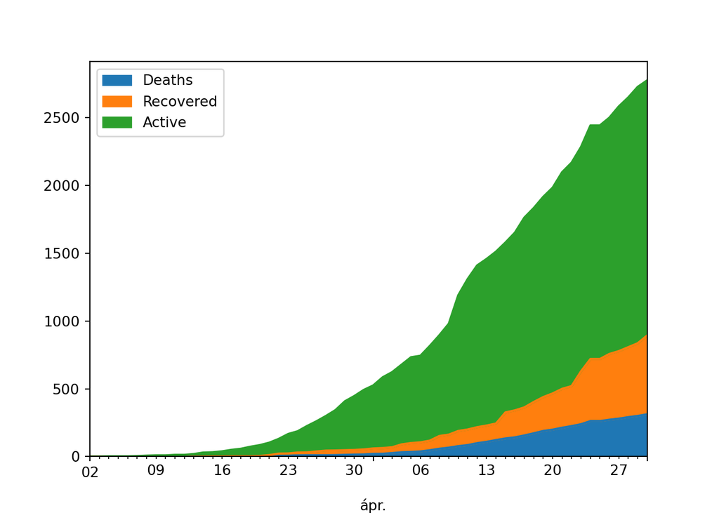

```python
Hungary.plot.area(x="Date", y=["Deaths", "Recovered", "Active"], stacked=True)
```

## 8. Aggregálás data frame-ben

Szűrjük le a corona dataframe-ből a legfrissebb adatokat minden országra egy új, corona_latest dataframe-be!  
Maximum függvényünk a `numpy` csomagból, tehát az `np` névtérből van.

```python
corona_latest = corona[corona['Date']==np.max(corona['Date'])]
corona_latest.info()
```

```
## <class 'pandas.core.frame.DataFrame'>
## Int64Index: 264 entries, 26136 to 26399
## Data columns (total 9 columns):
##  #   Column          Non-Null Count  Dtype
## ---  ------          --------------  -----
##  0   Province/State  264 non-null    object
##  1   Country/Region  264 non-null    object
##  2   Lat             264 non-null    float64
##  3   Long            264 non-null    float64
##  4   Date            264 non-null    datetime64[ns]
##  5   Confirmed       264 non-null    int64
##  6   Deaths          264 non-null    int64
##  7   Recovered       264 non-null    int64
##  8   Active          264 non-null    int64
## dtypes: datetime64[ns](1), float64(2), int64(4), object(2)
## memory usage: 20.6+ KB
```

Itt mivel egy ország akár lehet több régióval is jelen a sorok között országnév szerint össze tudjuk adni az összes megerősített koronavírusos esetet (*Confirmed* oszlop elemei). Magyarul **ország szintre szeretnénk összeg segítségével aggregálni** a megerősített koronavírus esetek számát.

Ehhez először a data frame `groupby` metódusával csoportosítani kell a sorokat ország szintre, majd megadni az összegzendő oszlopot és elsütni ezen oszlop `sum` metódusát az összegzéshez. Ha a `sum`-ot `avg`-re vagy `median`-ra cseréljük, akkor a kiválasztott oszlopnak nem az összegét, hanem az átlagát, illetve mediánját tudjuk nézni országok szerint. Azaz **átlaggal/mediánnal is aggregálhatunk az országok szintjére**.

```python
corona_country = corona_latest.groupby('Country/Region')['Confirmed'].sum()

corona_country.info()
```

```
## <class 'pandas.core.series.Series'>
## Index: 187 entries, Afghanistan to Zimbabwe
## Series name: Confirmed
## Non-Null Count  Dtype
## --------------  -----
## 187 non-null    int64
## dtypes: int64(1)
## memory usage: 2.9+ KB
```

```python
corona_country.head()
```

```
## Country/Region
## Afghanistan    2171
## Albania         773
## Algeria        4006
## Andorra         745
## Angola           27
## Name: Confirmed, dtype: int64
```

Az eredmény nem egy data frame, hanem mint láthatjuk egy `Series` lett, ami ugyebár logikailag egy `numpy` tömb! Mivel a `groupby` során az országok nevéből lett az új sorindex, így csak 1 oszlopunk maradt, az összegzett megerősített esetszám.

Ha azt szeretnénk, hogy a **corona_country**-ben az országok neve ne indexként, hanem külön oszlopként szerepeljen, akkor használjuk a `reset_index()` metódust!

```python
corona_country = corona_country.reset_index()

corona_country.info()
```

```
## <class 'pandas.core.frame.DataFrame'>
## RangeIndex: 187 entries, 0 to 186
## Data columns (total 2 columns):
##  #   Column          Non-Null Count  Dtype
## ---  ------          --------------  -----
##  0   Country/Region  187 non-null    object
##  1   Confirmed       187 non-null    int64
## dtypes: int64(1), object(1)
## memory usage: 3.0+ KB
```

```python
corona_country.head()
```

```
##   Country/Region  Confirmed
## 0    Afghanistan       2171
## 1        Albania        773
## 2        Algeria       4006
## 3        Andorra        745
## 4         Angola         27
```

Amennyiben a `groupby` metódus után egy általánosabb `agg` metódust használunk, akkor a `groupby`-ban megadott csoportosítás szerint egyszerre több művelet segítségével is összesíthetjük, azaz aggregálhatjuk a számértékű oszlop értékeit (pl. egyszerre nézünk átlagos és medián esetszámokat), Vagy akár több számértékű oszlopot is aggregálhatunk a `groupby` paraméterei szerint (pl. egyszerre nézünk átlagos esetszámot és halálozást is). Ráadásul, el is tudjuk nevezni az `agg` függvényen belül az újonnan létrehozott összesítő, azaz aggregált oszlopokat!  
Annyi trükk van a dologban, hogy az aggregáláshoz használt függvényeket (medián, átlag, szórás, stb.) a `numpy` csomagból szedjük ki az `np.` előtaggal!

Szóval a következő kódrészletben az `AtlagAktiv = ("Active", np.mean)` rész azt jelenti majd pl, hogy az *AtlagAktiv* oszlop a létrehozandó kimutatástáblában az eredeti data frame *Active* oszlopának átlaggal, azaz `np.mean` függvényével országos szintre összesített (“*groupby*”-olt) értékeit tartalmazza.

Na, akkor mostmár tényleg készítsünk el egy ország szintű kimutatást az átlagos és medián aktív koronavírus eseteiről, illetve átlagos és medián halálozási számairól a legfrisebb dátumra! Azt is megtehetjük, hogy már az aggregáló kód végére rögtön odatoljuk a `reset_index`-et.

```python
corona_kimutatas = corona_latest.groupby('Country/Region').agg(
  AtlagAktiv = ("Active", np.mean),
  MedianAktiv = ("Active", np.median),
  AtlagHalal = ("Deaths", np.mean),
  MedianHalal = ("Deaths", np.median)
).reset_index()

corona_kimutatas
```

```
##          Country/Region  AtlagAktiv  MedianAktiv  AtlagHalal  MedianHalal
## 0           Afghanistan      1847.0       1847.0        64.0         64.0
## 1               Albania       272.0        272.0        31.0         31.0
## 2               Algeria      1777.0       1777.0       450.0        450.0
## 3               Andorra       235.0        235.0        42.0         42.0
## 4                Angola        18.0         18.0         2.0          2.0
## ..                  ...         ...          ...         ...          ...
## 182  West Bank and Gaza       266.0        266.0         2.0          2.0
## 183      Western Sahara         1.0          1.0         0.0          0.0
## 184               Yemen         4.0          4.0         2.0          2.0
## 185              Zambia        48.0         48.0         3.0          3.0
## 186            Zimbabwe        31.0         31.0         4.0          4.0
##
## [187 rows x 5 columns]
```

Azt látjuk, hogy az átlag és medián értékek mind az aktív esetek számára, mind a halálozási számokra megegyeznek. Ez azért van, mert a legtöbb ország ugyebár nem volt lebontva államokra és provinciákra, szóval egy nap csak egy érték érkezett a táblába rájuk mindenből. Egy értéknek pedig nyilván ugyan az az átlaga és a mediánja is! :)

Na, de lessünk meg pár olyan országot, ahol az adatok belső régiókra, provinciákra is le voltak bontva. Pl. Franciaország és az Egyesült Királyság ilyen országok voltak:

```python
corona_kimutatas[corona_kimutatas["Country/Region"].isin(["France", "United Kingdom"])]
```

```
##      Country/Region    AtlagAktiv  MedianAktiv   AtlagHalal  MedianHalal
## 62           France   8409.909091         31.0  2219.090909          1.0
## 177  United Kingdom  13161.818182         13.0  2440.181818          1.0
```

Na itt már látszik az eltérés! Pl. a francia tartományok felében legfeljebb $31$ aktív koronavírusos eset volt csak 2020.04.30-án, de a tartományok átlagában az érték már kerektíve $8410$ eset! Ezt valószínűleg egy vagy kettő kiugróan sok esettel rendlkező tartomány okozza csak!

## 9. Egyszerű leíró statisztika data frame-ben

No, de most térjünk vissza a **corona_country** data frame-hez! Egyszerűsítsük az oszlopneveket! A data frame-k `columns` tulajdonságának felülírásával az oszlopnevek könnyen módosíthatók. Mivel ugye a `columns` tulajdonságban az összes oszlopnév szerepel listaként, így az új oszlopneveket listaként felsorolva [] jellel kell megadni.

```python
corona_country.columns=['Country', 'COVID_Cases']

corona_country.info()
```

```
## <class 'pandas.core.frame.DataFrame'>
## RangeIndex: 187 entries, 0 to 186
## Data columns (total 2 columns):
##  #   Column       Non-Null Count  Dtype
## ---  ------       --------------  -----
##  0   Country      187 non-null    object
##  1   COVID_Cases  187 non-null    int64
## dtypes: int64(1), object(1)
## memory usage: 3.0+ KB
```

Nézzünk egy komplett leíró statisztikát a *COVID_Cases* változóra/ismérvre/oszlopra a `describe` metódus segítségével. Kerekítsük az eredményeket 2 tizedesjegyre (`round` függvény).

```python
round(corona_country.COVID_Cases.describe(),2)
```

```
## count        187.00
## mean       17416.26
## std        84414.11
## min            1.00
## 25%           97.50
## 50%          746.00
## 75%         6254.50
## max      1069424.00
## Name: COVID_Cases, dtype: float64
```

Nézzük meg ezt az ordenáré módon jobbra elnyúló eloszlást hisztogramon és doboz ábrán is!

A hisztogramot simán a vizsgált oszlop `hist` metódusával le lehet kérni.

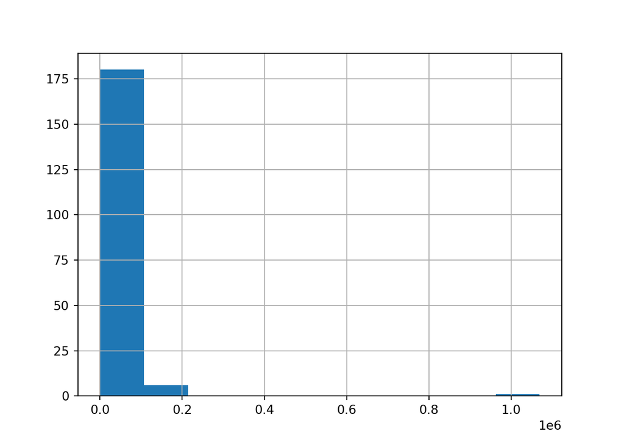

```python
corona_country.COVID_Cases.hist()
```

Alapból egyenlő hosszúságú osztályközötket képez a pitonállat a hisztogramokhoz, aminek a számát a `hist` függvényben a `bins` paraméteren keresztül tudjuk szabályozni.

Vigyük le pl. az osztályközök számát $5$-re.

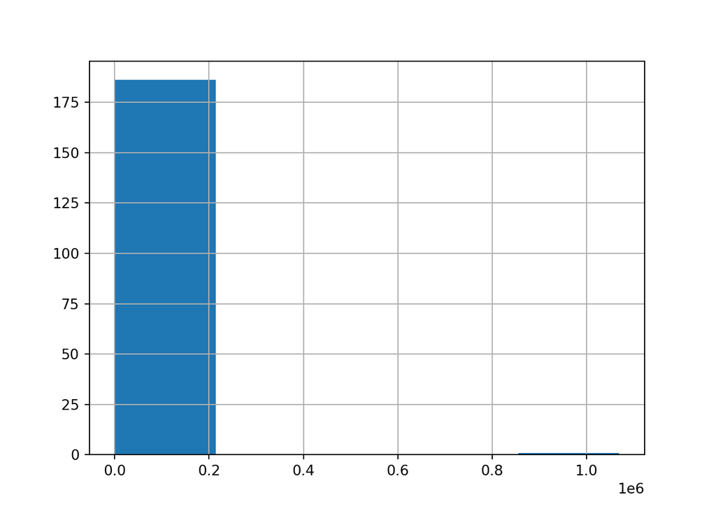

```python
corona_country.COVID_Cases.hist(bins=5)
```

A `boxplot` metódus már alapvetően data frame, és nem oszlop szinten működik, és a metódus paraméterében kell megadni, hogy mely oszlopra vagy oszlopokra (neveket listaként felsorolva [] jellel) akarjuk az ábrát. Tehát, a doboz ábrát egyszerre több oszlopra is lekérhetjük egy ábrán belülre akár. Majd mindjárt nézünk ilyet is. Ennek a doboz ábránál van értelme, hiszen doboz ábránál nincsenek osztályközök, amiknek a számát esetlegesen az ismérvünk (oszlopunk) eloszlására kell szabni.

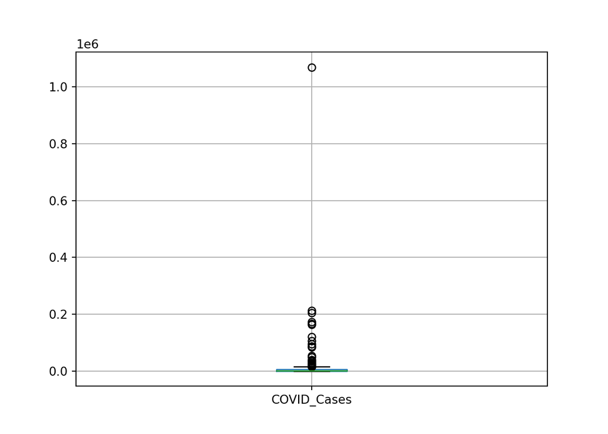

```python
corona_country.boxplot(column="COVID_Cases")
```

## 10. Adatminőségi problémák felismerése és kezelése leíró statisztika segítségével

Olvassuk be a population_by_country_2020.csv nevű fájlt, és mentsük el a beolvasott adatokat egy **population** nevű data frame-be!

```python
population = pd.read_csv('population_by_country_2020.csv')
population.info()
```

```
## <class 'pandas.core.frame.DataFrame'>
## RangeIndex: 235 entries, 0 to 234
## Data columns (total 11 columns):
##  #   Column                   Non-Null Count  Dtype
## ---  ------                   --------------  -----
##  0   Country (or dependency)  235 non-null    object
##  1   Population (2020)        235 non-null    int64
##  2   Yearly Change            235 non-null    object
##  3   Net Change               235 non-null    int64
##  4   Density (P/Km²)          235 non-null    int64
##  5   Land Area (Km²)          235 non-null    int64
##  6   Migrants (net)           201 non-null    float64
##  7   Fert. Rate               235 non-null    object
##  8   Med. Age                 235 non-null    object
##  9   Urban Pop %              235 non-null    object
##  10  World Share              235 non-null    object
## dtypes: float64(1), int64(4), object(6)
## memory usage: 20.3+ KB
```

A **population** dataframe-ből csak az országnév, népesség, népsűrűség és városi népesség aránya változókra lesz szükségünk.  
A többit törölhetjük is a data frame-ből! Mivel az oszlopnevekben mint fentebb láthatjuk elég sok a hányadék módon speciális karakter, így biztonságosabb most az oszlopokra a sorszámukkal hivatkozni. Láthatjuk az `info` metódus eredményéből, hogy a szükséges országnév, népesség, népsűrűség és városi népesség aránya oszlopok rendre a $0,1,4,9$ indexekkel bírnak.

```python
population = population.iloc[:,[0, 1, 4, 9]]

population.info()
```

```
## <class 'pandas.core.frame.DataFrame'>
## RangeIndex: 235 entries, 0 to 234
## Data columns (total 4 columns):
##  #   Column                   Non-Null Count  Dtype
## ---  ------                   --------------  -----
##  0   Country (or dependency)  235 non-null    object
##  1   Population (2020)        235 non-null    int64
##  2   Density (P/Km²)          235 non-null    int64
##  3   Urban Pop %              235 non-null    object
## dtypes: int64(2), object(2)
## memory usage: 7.5+ KB
```

Egyszerűsítsük az oszlopneveket a population dataframe-ben!

```python
population.columns = ['Country', 'Pop', 'PopDensity', 'UrbanPop']

population.info()
```

```
## <class 'pandas.core.frame.DataFrame'>
## RangeIndex: 235 entries, 0 to 234
## Data columns (total 4 columns):
##  #   Column      Non-Null Count  Dtype
## ---  ------      --------------  -----
##  0   Country     235 non-null    object
##  1   Pop         235 non-null    int64
##  2   PopDensity  235 non-null    int64
##  3   UrbanPop    235 non-null    object
## dtypes: int64(2), object(2)
## memory usage: 7.5+ KB
```

Nézzük meg a population dataframe egyszerű leíró statisztikai mutatóit! Ha a `describe` metódust az egész data frame-n engedjük el, akkor minden numerikus (`int` vagy `float`) oszlopra megadja az alap leíró mutatókat.

```python
round(population.describe(), 2)
```

```
##                 Pop  PopDensity
## count  2.350000e+02      235.00
## mean   3.316936e+07      475.77
## std    1.351374e+08     2331.29
## min    8.010000e+02        0.00
## 25%    3.988760e+05       37.00
## 50%    5.459642e+06       95.00
## 75%    2.057705e+07      239.50
## max    1.439324e+09    26337.00
```

Az *UrbanPop* változónak mi baja? Elviekben az egy arányszám, annak is számnak kéne lennie, és meg kéne jelennie a `describe` metódus eredményében!

Kukkantsunk csak bele a data frame első 5 sorába!

```python
population.head()
```

```
##          Country         Pop  PopDensity UrbanPop
## 0          China  1439323776         153      61%
## 1          India  1380004385         464      35%
## 2  United States   331002651          36      83%
## 3      Indonesia   273523615         151      56%
## 4       Pakistan   220892340         287      35%
```

Áhhá! Százalékjel van benne! Ezért veszi szöveges adatnak a pitonállat!

Szedjük le ezt a százalékjelet! Erre szerencsére az egyes data frame oszlopoknak van egy `str.replace` metódusa, amiben megadhatjuk paraméterekkel, hogy az oszlopban milyen szövegrészleteket mire akarunk cserélni. Itt most ugyebár százalékjelet fogunk üres stringre cserélni.

```python
population['UrbanPop'] = population['UrbanPop'].str.replace('%', '')

population.head()
```

```
##          Country         Pop  PopDensity UrbanPop
## 0          China  1439323776         153       61
## 1          India  1380004385         464       35
## 2  United States   331002651          36       83
## 3      Indonesia   273523615         151       56
## 4       Pakistan   220892340         287       35
```

Ez jó, de sajnos vannak benne hiányzó értékek, amik nem a szabványos Python `NaN` kóddal vannak jelölve, hanem ilyen spéci *“N.A.”* stringgel, amit a gépállat nem ismer fel, így az egész oszlopot `str`-nek (`object`) veszi a `numpy` tömbök egységes adattípus logikája alapján.

```python
population.info()
```

```
## <class 'pandas.core.frame.DataFrame'>
## RangeIndex: 235 entries, 0 to 234
## Data columns (total 4 columns):
##  #   Column      Non-Null Count  Dtype
## ---  ------      --------------  -----
##  0   Country     235 non-null    object
##  1   Pop         235 non-null    int64
##  2   PopDensity  235 non-null    int64
##  3   UrbanPop    235 non-null    object
## dtypes: int64(2), object(2)
## memory usage: 7.5+ KB
```

Azt, hogy az `object` adattípus turpisságát az “N.A.”-k okozzák az UrbanPop oszlopban, arra leginkább az oszlop gyakorisági táblájából lehet felismerni. Ezt a gyakorisági táblát az oszlop `value_counts` metódusával tudjuk lekérni.

```python
population.UrbanPop.value_counts()
```

```
## N.A.    13
## 57       7
## 88       7
## 63       6
## 87       6
##         ..
## 50       1
## 81       1
## 28       1
## 37       1
## 10       1
## Name: UrbanPop, Length: 81, dtype: int64
```

Láthatjuk, hogy a sok számérték mellett, 13 ország esetén hiányzó értékünk van ezzel a csúnya “N.A.” kóddal.

Na, akkor! Most csináljuk azt, hogy leszűrjük azt a 13 országot, ahol hiányzik a városi népesség arányára vonatkozó adat!

Ezek után próbáljuk meg a városi népesség arányára vonatkozó adatot `int` típusúvá konvertálni! Ha sikerült, nézzük meg a változó alap leíró statisztikai mutatóit is!

Először logikai indexszeléssel leszűrjük az “N.A.”-kat.

```python
population = population[population['UrbanPop']!="N.A."]
```

Majd az oszlop `astype` metódusával `int`-é konvertáljuk az egész oszlopot. A metódus paraméterében kell megadni, hogy milyen adattípusra akarjuk konvertálni kiszemelt kis oszlopunk! :) Végül jöhet a `describe`.

```python
population['UrbanPop'] = population['UrbanPop'].astype(int)

population.describe()
```

```
##                 Pop   PopDensity    UrbanPop
## count  2.220000e+02   222.000000  222.000000
## mean   3.488611e+07   186.373874   59.234234
## std    1.388508e+08   288.271695   24.230400
## min    1.357000e+03     0.000000    0.000000
## 25%    5.444048e+05    35.000000   43.000000
## 50%    5.911701e+06    89.000000   60.500000
## 75%    2.321589e+07   224.500000   79.000000
## max    1.439324e+09  2239.000000  100.000000
```

## 11. Data frame-k összekapcsolása

Akkor most álmodjunk egy nagyot! Kössük össze a **population** data frame-ben található országonkénti alapvető demográfiai ismérveket a **corona_country** data frame-ben lakó országonkénti koronavírus esetszámokkal.

Nyilván ezt az összekötést az országok nevén keresztül lehet megtenni. Azaz pl. a magyar koronavírus esetszámokhoz a magyar demográfiai adatoknak kell kerülnie értelemszerűen. :)

A `pandas` csomagnak létezik egy `merge` névre hallgató függvénye, ami két data frame-et összeköt egy előre megadott közös oszlop alapján. Esetünkben ez a közös oszlop az országnév lesz.  
Ha egy kicsit “*adatbázisabbul*” szeretném kifejezni magam, akkor azt mondanám, hogy a `merge` függvény 2 tábla joinját oldja meg egy közös kulcs alapján.

Sőt, a `merge` függvény mindhárom alapvető táblakapcsolási módszert támogatja:

- **inner join**: Az összekötött táblában csak azok a sorok maradnak meg, amelyek mindkét data frame-ben szerepelnek.
- **left join**: Az összekötött táblában csak azok a sorok maradnak meg, amelyek az elsőre megnevezett data frame-ben szerepelnek (attól függetlenül, hogy a másodszorra megnevezett táblában van-e hozzájuk találat).
- **right join**: Az összekötött táblában csak azok a sorok maradnak meg, amelyek a másodszorra megnevezett data frame-ben szerepelnek (attól függetlenül, hogy az elsőre megnevezett táblában van-e hozzájuk találat).
- **full outer join**: Az összekötött táblában mindkét tábla minden sora megmarad.

A különböző típusú összekötési módokat remekül lehet halmazábrákkal szemléltetni:

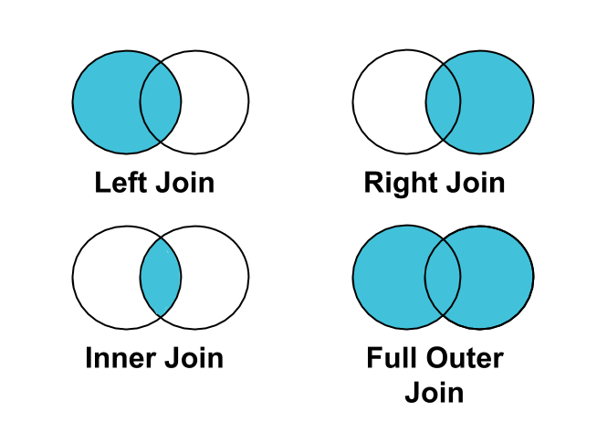

Na, akkor mielőtt a tényleges `merge`-hez hozzálátunk, annyit ellenőrizzünk le, hogy ugyanaz-e a neve az országneveket tartalmazó oszlopnak mindkét data frame-ben, a **population**ben és a **corona_country**-ban is:

```python
corona_country.columns
```

```
## Index(['Country', 'COVID_Cases'], dtype='object')
```

```python
population.columns
```

```
## Index(['Country', 'Pop', 'PopDensity', 'UrbanPop'], dtype='object')
```

Szuper, mindkét táblában egységesen **‘Country’** az összekötésre használandó oszlop neve! Nem meglepő, mert mindkét táblában átneveztük már korábban az oszlopokat, de azért jobb biztosra menni. :)

Akkor lássuk azt a `merge`-t! Most egy olyan összekötést csinálunk, hogy a **corona_country** táblában lévő összes sorunk maradjon meg az összekötött táblában, mert alapvetően azok az országok érdekelnek, ahol megvan a COVID fertőzöttek száma. Ez az én data frame megadási sorrendben majd egy *left join*t fog jelenteni. :)

A `merge` függvényben a két data frame megadása után a `how` paraméter szabályozza a *join* jellegét, míg az `on` paraméterben adjuk meg az összekötésre használt oszlop nevét. A *join* tehát azért lesz *left*, mert a **corona_country**-t adtam meg először, azaz “*balrább*”. :)

```python
corona_extended = pd.merge(corona_country, population, how='left', on='Country')
corona_extended.info()
```

```
## <class 'pandas.core.frame.DataFrame'>
## Int64Index: 187 entries, 0 to 186
## Data columns (total 5 columns):
##  #   Column       Non-Null Count  Dtype
## ---  ------       --------------  -----
##  0   Country      187 non-null    object
##  1   COVID_Cases  187 non-null    int64
##  2   Pop          168 non-null    float64
##  3   PopDensity   168 non-null    float64
##  4   UrbanPop     168 non-null    float64
## dtypes: float64(3), int64(1), object(1)
## memory usage: 8.8+ KB
```

Na, hát az új data frame `info` metódusa alapján van egy kis probléma. $187-168=19$ országra a **corona_country** data frame-ben nem volt találat a **population** data frame-ben.

### 11.1. A kapcsolási kulcsnak használt oszlop ellenőrzése és javítása

Lessük meg mik ezek az országok, ahol nem volt találat a **population** data frame-ben! Ezt pl. úgy tudjuk megtenni, hogy lekérdezzük a hiányzó értékek országát a **Pop** oszlopban.

```python
corona_extended.Country[corona_extended.Pop.isnull()==True]
```

```
## 27                                Burma
## 39                  Congo (Brazzaville)
## 40                     Congo (Kinshasa)
## 42                        Cote d'Ivoire
## 46                              Czechia
## 48                     Diamond Princess
## 75                             Holy See
## 91                               Kosovo
## 92                               Kuwait
## 102                          MS Zaandam
## 113                              Monaco
## 140               Saint Kitts and Nevis
## 142    Saint Vincent and the Grenadines
## 144               Sao Tome and Principe
## 150                           Singapore
## 164                             Taiwan*
## 173                                  US
## 180                           Venezuela
## 182                  West Bank and Gaza
## Name: Country, dtype: object
```

Elnézegetve az országneveket kialakulhat bennünk valami sejtés: valószínűleg ezeket az országokat máshogy hívják a **population** data frame-ben, mint a **corona_country**-ban. Pl. *Taiwan* nevében valószínűleg nem lesz csillag, vagy *Czechia*-t inkább a hivatalosabb nevén jegyezheti a **population** tábla: *Czech Republic*. Esetleg a *US* is inkább *United States*-ként szerepelhet.

Teszteljük le ezeket az elméleteket egy egyszerű logikai indexes szűréssel az `isin` metódussal megtámogatva.

```python
population.Country[population.Country.isin(["Czech Republic", "Taiwan", "United States"])]
```

```
## 2     United States
## 56           Taiwan
## Name: Country, dtype: object
```

Mintha bejönne az okoskodásunk, de a cseheket csak nem akarja megtalálni a cucc. Próbáljunk meg úgy szűrni, hogy ne pontosan keressük ezeket az országneveket, hanem azt nézzük meg, hogy mik azok a sorok a **population** data frame-ben, amik ezeket az országneveket *tartalmazzák* valahol a **Country** oszlopban.  
Ezt egyszerűen el tudjuk érni úgy, hogy az előző kódunkban az `isin` metódust `str.contains`-re cseréljük. Annyi van, hogy itt a keresett string mintázatokat egy stringben kell megadni (azaz NEM listaként) “|” jellel elválasztva őket.  
Ez így amúgy egy úgynevezett [RegEx kifejezés](http://vbence.web.elte.hu/regex_leiras.html), és ilyenekkel lehet komplexebben működtetni ezt a `str.contains` metódust. Az érdeklődőknek jó kiindulópont a link. :)

```python
population.Country[population.Country.str.contains("Czech Republic|Taiwan|United States")]
```

```
## 2                United States
## 56                      Taiwan
## 85    Czech Republic (Czechia)
## Name: Country, dtype: object
```

Ó, hogy a kedves felmenőiket a **population** data frame alkotóinak: hát nem ott van zárójelben a *Czech Republic* mögött, hogy *Czechia*?! “*Ripsz!*”

Hát valami hasonló módon be kéne lőni a maradék 16 nem egyező országnevet is, de most ezzel nem húzzuk a drága időnket, hanem javítjuk ezt a 3 esetet és újra összekötjük a tábláinkat.  
Aki a nem egyértelmű kapcsoló oszlop (kulcs) alapján történő data frame összekötés világában szeretne elmélyedni, neki érdemes lehet majd előbb-utóbb utána néznie a *fuzzy join* technikáknak, amiket a Pythonban pl. a [difflib csomag támogat](https://stackoverflow.com/questions/13636848/is-it-possible-to-do-fuzzy-match-merge-with-python-pandas). De ezek a megoldások az itteni bevezető példának a kereteit bőven megugorják komplexitásban.

Szóval, akkor a 3 azonosított eltérő országnevet javítsuk a **population** data frame-ben. Azaz ott átírjuk ezeket az országneveket arra a verzióra, ami a **corona_country**-ban is szerepel. Ehhez megint az `str.replace`-t használjuk, mint anno az **UrbanPop** oszlop százalékjeleinek eltávolításakor. Ezt mindhárom esetben külön meg kell sajnos tenni.

```python
population['Country'] = population['Country'].replace('United States', 'US')
population['Country'] = population['Country'].replace('Czech Republic (Czechia)', 'Czechia')
population['Country'] = population['Country'].replace('Taiwan', 'Taiwan*')
```

És akkor lássuk újra azt a `merge`-t! Most a többi nem kezelt esetet eldobjuk, szóval *inner join*t csinálunk.

```python
corona_extended = pd.merge(corona_country, population, how='inner', on='Country')
corona_extended.info()
```

```
## <class 'pandas.core.frame.DataFrame'>
## Int64Index: 171 entries, 0 to 170
## Data columns (total 5 columns):
##  #   Column       Non-Null Count  Dtype
## ---  ------       --------------  -----
##  0   Country      171 non-null    object
##  1   COVID_Cases  171 non-null    int64
##  2   Pop          171 non-null    int64
##  3   PopDensity   171 non-null    int64
##  4   UrbanPop     171 non-null    int32
## dtypes: int32(1), int64(3), object(1)
## memory usage: 7.3+ KB
```

Szupszi! Már nem $168$ sor van, amire van találat mindkét data frame-ben, mint az előbb, hanem $171$, azaz pont a megjavított $3$ országgal több! Na, erre már elő lehet venni az ünnepi laposüveget (leánykori nevén lapiüvit)! ;)

## 12. Kilógó értékek keresése és kezelése

A sikeres data frame összekötési művelet örömére, számoljuk ki a **corona_extended** dataframe-ben az egymillió főre jutó COVID-19 esetek számát minden országra! Aztán nézzük is meg az oszlop leíró statisztikáit!

```python
corona_extended['COVID_perMillion'] = corona_extended.COVID_Cases / corona_extended.Pop * 1000000
corona_extended['COVID_perMillion'].describe()
```

```
## count      171.000000
## mean       747.439425
## std       1775.534029
## min          0.201167
## 25%         19.420289
## 50%        119.830206
## 75%        700.197689
## max      16769.325985
## Name: COVID_perMillion, dtype: float64
```

Na, szuper, itt is látszik egy csodás jobbra elnyúló eloszlás, hiszen az országok $\frac{3}{4}$-ének az egymillió főre vetített COVID esetszáma nem haladja meg a $700$-at, de ellenben a legnagyobb érték már majdnem $17$ ezer fő! Ellenben az alsó $25\%$ határa, a $19.4$ egészen közel van a minimumhoz, a $0.2$-höz. Szóval valószínűleg brutál felfelé kilógó elemeink vannak.

Ezt erősítsük is meg egy doboz ábrán.

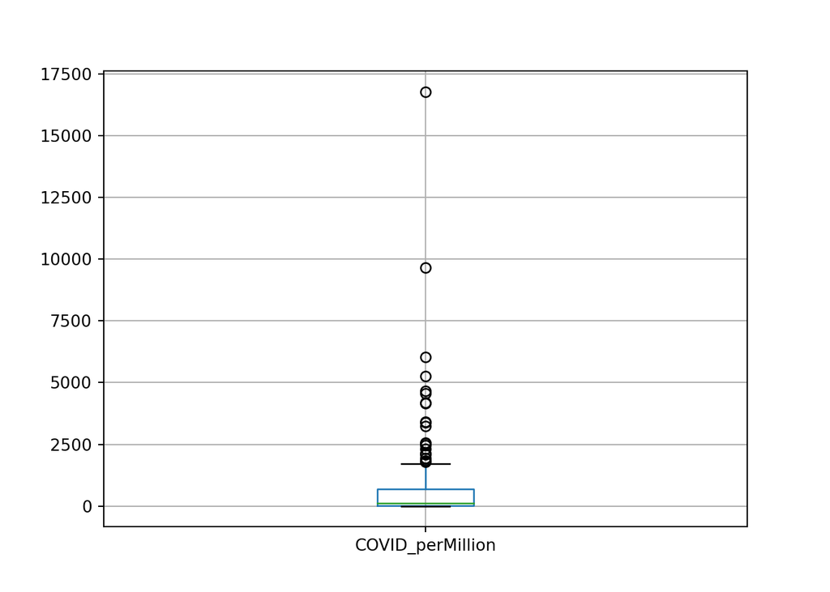

```python
corona_extended.boxplot(column="COVID_perMillion")
```

Az ábra alapján nagyjából olyan 3000 feletti értékek tűnnek extrém módon kilógónak (kb. 3000-nél van az első szakadás a dobozban a ponttal jelölt kilógó értékek körében; a szakadás alatti részek, még kb a normál adatok “természetes” folytatásának tekinthetők). Lássuk hát, hogy mik ezek!

Rendezzük a **COVID_perMillion** szerint csökkenő sorrendbe a data frame-t, és kérjük le a sorbarendezett verzióból azokat az értékeket, ahol a **COVID_perMillion** nagyobb, mint 3000!

```python
corona_extended.sort_values('COVID_perMillion', ascending=False).loc[corona_extended['COVID_perMillion'] > 3000,:]
```

```
##          Country  COVID_Cases  ...  UrbanPop  COVID_perMillion
## 131   San Marino          569  ...        97      16769.325985
## 3        Andorra          745  ...        88       9642.140685
## 93    Luxembourg         3784  ...        88       6044.940877
## 72       Iceland         1797  ...        94       5266.042087
## 126        Qatar        13409  ...        96       4654.201086
## 143        Spain       213435  ...        80       4564.987989
## 16       Belgium        48519  ...        98       4186.417453
## 77       Ireland        20612  ...        63       4174.340484
## 148  Switzerland        29586  ...        74       3418.520185
## 79         Italy       205463  ...        69       3398.226842
## 159           US      1069424  ...        83       3230.862341
##
## [11 rows x 6 columns]
```

Na, úgy néz ki, hogy az érintett országok töbségében ilyen jó kicsi, zsúfolt államok. Persze vannak extrém kivételek, pl. ugye az olaszok a nagy repülős turistaforgalmuk miatt.

Na, ezeket az extrém módon kilógó értékeket kipucoljuk a data frame-ből, aztán ránézünk újra a **COVID_perMillion** doboz ábrájára. Most a kilógó értékeket vegyük csak a 4000 feletti esetszámoknak, mivel a sorrend alapján van egy nagyobb ugrás ott a svájci 3418-ról az ír 4174-re. Meg a doboz ábrán is látszik, hogy ez az utolsó 3 érték ebben a “toplistában” még azért közelebb van az adatok “természetes folytatásához”, és utána jön még egy ugrás az egymillió főre vetített esetszámokban.

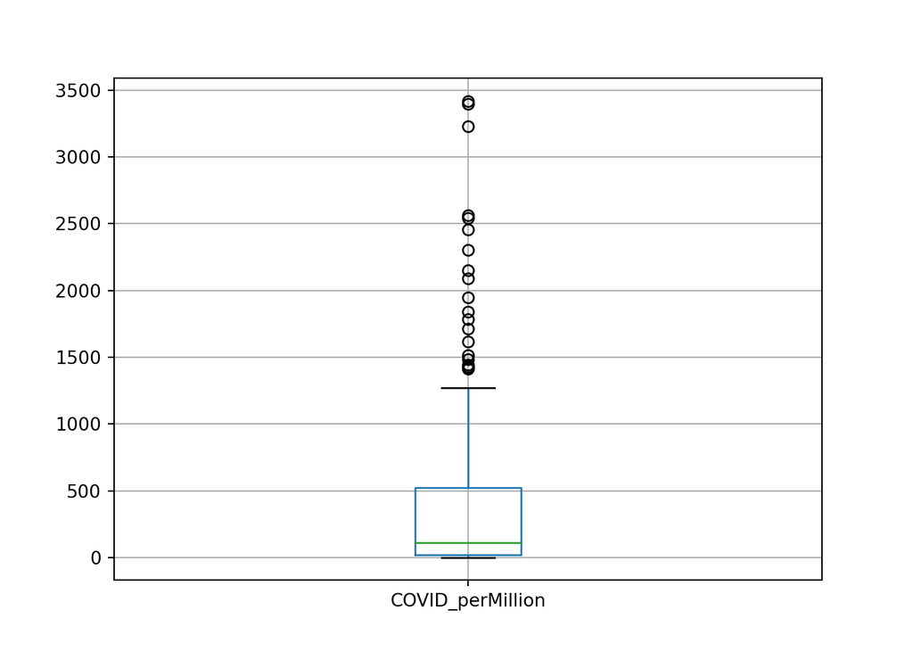

```python
corona_extended = corona_extended[corona_extended['COVID_perMillion'] < 4000]
corona_extended.boxplot(column="COVID_perMillion")
```

Ez már egy kulturáltabb jobbra elnyúló eloszlás. Viszont, a medián még mindig túlságosan közel van az alsó kvartilishez, és a felső kvartilis eléggé elszakad.

Ennek szellemében még nézzünk rá arra, hogy mely országok esnek az egymillió főre jutó COVID esetszám szerint az alsó kvintilisbe!

Egy data frame oszlop alsó kvintilisét az oszlop `quantile` metódusával számoljuk ki. A metódus alapvetően egy tetszőleges percentilist számol ki. Azt, hogy melyiket, azt a metódus paraméterében kell megadni $0-1$ közötti számként. Szóval az alsó kvintilis alias 20. percentilis, ami alatt az adatok $20\%$-a található, egy $0.2$ paraméterrel lesz megadható.

```python
corona_extended['COVID_perMillion'].quantile(0.2)
```

```
## 10.058723607815136
```

Ezt a fenti kódot felhasználva egy logikai indexes szűrésben gyorsan meg is lesznek a népességarányos esetszám szerinti alsó kvintilisbe tartozó országok nevei is.

```python
corona_extended[corona_extended['COVID_perMillion'] <
               corona_extended['COVID_perMillion'].quantile(0.2)]
```

```
##               Country  COVID_Cases  ...  UrbanPop  COVID_perMillion
## 4              Angola           27  ...        67          0.821511
## 18              Benin           64  ...        48          5.279134
## 19             Bhutan            7  ...        46          9.071964
## 22           Botswana           23  ...        73          9.780463
## 27            Burundi           11  ...        14          0.925086
## 29           Cambodia          122  ...        24          7.297102
## 33               Chad           73  ...        23          4.444211
## 37            Comoros            1  ...        29          1.149953
## 54           Ethiopia          131  ...        21          1.139491
## 59             Gambia           11  ...        59          4.551722
## 69              Haiti           81  ...        57          7.103688
## 84              Kenya          396  ...        28          7.364524
## 86               Laos           19  ...        36          2.611483
## 90              Libya           61  ...        78          8.877515
```

[output cut: 21 more lines]

Az eredmények alapján úgy néz ki, hogy az egymillió főre jutó COVID esetszám szerinti alsó kvintilisbe elsősorban olyan afrikai országok esnek, ahol még 2020.04.30-án egyelőre nem tört ki tömeges járvány!

Ezeket az országokat távolítsuk el a corona_country dataframe-ből!  
Majd ezután tekintsük meg ismét az egymillió főre jutó COVID esetszám hisztogramját, és doboz ábráját!

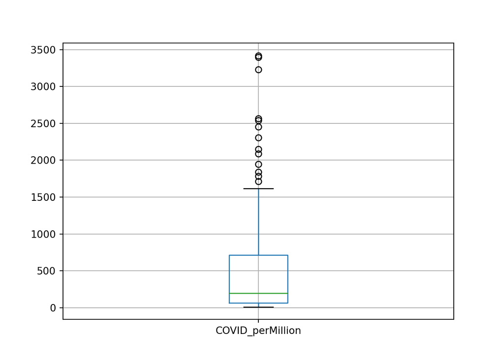

```python
corona_extended = corona_extended[corona_extended['COVID_perMillion'] >
                                corona_extended['COVID_perMillion'].quantile(.2)]

corona_extended.boxplot(column="COVID_perMillion")
```

Na, ez már kb úgy néz ki, mint egy “egészségesen” jobbra elnyúló eloszlás doboz ábrája! :)

## 13. Korrelációs elemzések data frame-ben

Nézzünk rá a numerikus adattípusú oszlopok közti korrelációs mátrixra. Egyedül a **Pop** és **COVID_Cases** oszlopokat hagyjuk ki a vizsgálatból, mert azok abszolút és nem népességarányos adatok, így csalóka lenne őket szerepeltetni a korrelációs vizsgálatokban, hiszen “triviálisan” korrelálnak: nagyobb népességű országban nyilván több az összes esetszám. :)

Azt, hogy csak két oszlopot ne válasszunk ki egy data frame-ben úgy tudjuk elérni, hogy a data frame oszlopnevei közül egy `isin` metódussal kiválasztjuk a két kihagyandó oszlopot, majd az eredményt letagadjuk egy `~` jellel. Ezt a műveletet pedig beágyazzuk egy `loc` metódusba, és meg is vagyunk! :)

```python
corona_extended.loc[:,~corona_extended.columns.isin(['COVID_Cases', 'Pop'])]
```

```
##                   Country  PopDensity  UrbanPop  COVID_perMillion
## 0             Afghanistan          60        25         55.769130
## 1                 Albania         105        63        268.608244
## 2                 Algeria          18        73         91.354724
## 5     Antigua and Barbuda         223        26        245.075514
## 6               Argentina          17        93         97.973762
## ..                    ...         ...       ...               ...
## 161               Ukraine          75        69        237.939741
## 162  United Arab Emirates         118        86       1261.930506
## 163        United Kingdom         281        83       2540.744366
## 164               Uruguay          20        96        185.103621
## 165            Uzbekistan          79        50         60.921678
##
## [130 rows x 4 columns]
```

Erre az oszlopaiban megvágott data frame-re pedig egy `corr` nevű metódust tudunk alkalmazni, ami megadja a numerikus oszlopok közti korrelációk mátrixszát. Szerencsére a pitonállat automatikusan figyelmen kívül hagyja a string típusú **Country** oszlopot és nem fut hibára! Okos ez a pitonka azért néha! :)

```python
corona_extended.loc[:,~corona_extended.columns.isin(['COVID_Cases', 'Pop'])].corr()
```

```
##                   PopDensity  UrbanPop  COVID_perMillion
## PopDensity          1.000000 -0.051282          0.118036
## UrbanPop           -0.051282  1.000000          0.341160
## COVID_perMillion    0.118036  0.341160          1.000000
```

A korrelációs mátrixból látszik, hogy az egymillió főre jutó COVID esetszám leginkább a városi népesség arányával függ össze, teljesen logikus módon: egyirányú, közepes erősségű a kapcsolat. A zsúfolt városi közösségi tereken, tömegközlekedésen könnyebb megfertőződni. :)

Nézzük is meg a kapcsolatot pontdiagramon! Teljesen úgy működik a pontdiagram is, mint pl. a korábbiakban a magyar adatokon látott területdiagram, csak a metódus neve nem `plot.area`, hanem `plot.scatter`. :)

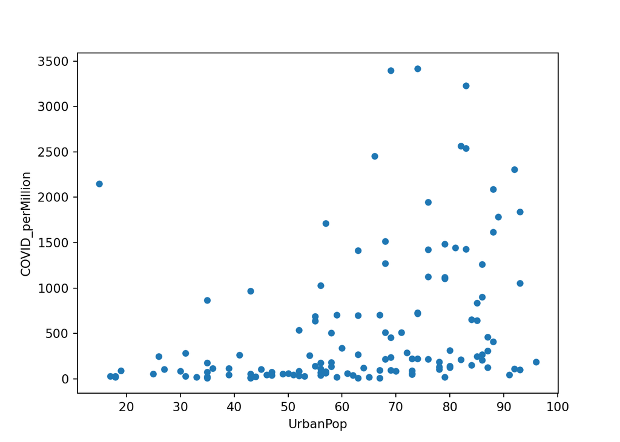

```python
corona_extended.plot.scatter(x="UrbanPop", y="COVID_perMillion")
```

A pontdiagramon azt vehetjük észre, hogy az egymillió főre jutó COVID esetszám jobbra elnyúló eloszlása miatt jelenlévő felfelé kiugró értékek befolyásolják a két ismérv kapcsolatát. A kilógóan magas esetszámok miatt úgy tűnik, mintha az 500 alatti esetszámú országokban nem is lenne kapcsolat a két ismérv között.  
A városi népesség arányával nincsenek ilyen problémák, mivel annak eloszlása közel szimmetrikus.

A két ismérv/oszlop eloszlásáról írtakat a hisztogramokon is meg lehet lesni.

Az egymillió főre jutó esetszám hisztogramja, ami elég jobbra elnyúló.

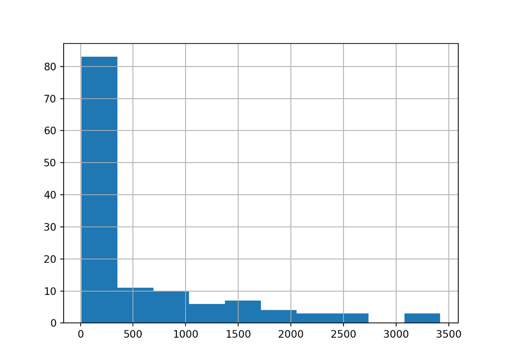

```python
corona_extended.COVID_perMillion.hist()
```

És a városi népesség arányáé, ami szimmetrikusabb egy fokkal, de némileg inkább balra elnyúló. A lényeg, hogy ezen nem segít a logaritmus. :)

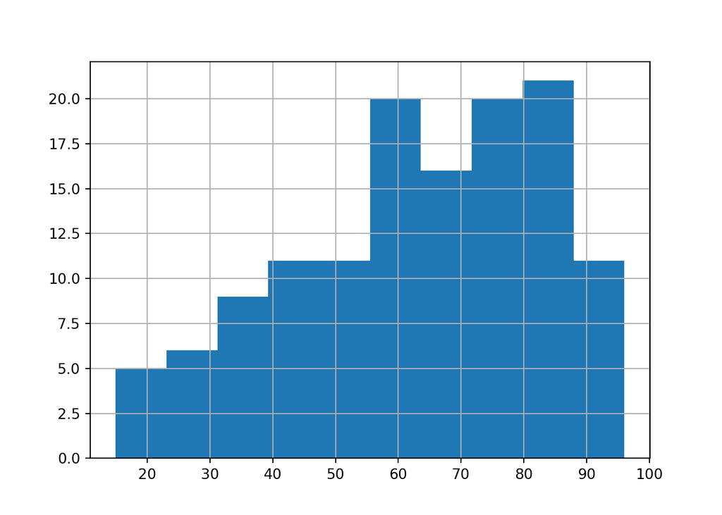

```python
corona_extended.UrbanPop.hist()
```

A kiugró értékek hatását, és az **eloszlás jobbra elnyúlóból közel szimmetrikussá alakítását logaritmussal** lehet elérni.

Készítsük is el a **COVID_perMillion** oszlop természetes alapú logaritmusát egy új oszlopban a data frame-n belül.

```python
corona_extended['log_COVID_perMillion'] = np.log(corona_extended['COVID_perMillion'])
```

Ezek után lessünk rá az új oszlop hisztogramjára:

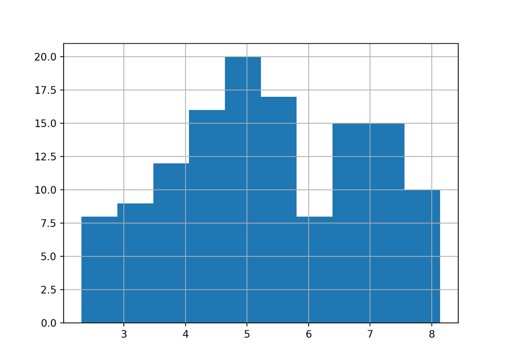

```python
corona_extended.log_COVID_perMillion.hist()
```

Sokkal szebb! :) Legalábbis szimmetria szempontjából biztos. Viszont van benne azért egy kétmóduszú jelleg. Ez azt jelenti, hogy van az országoknak egy jelentősebb csoportja, ahol emelkedettebb a népességarányos COVID esetszám, mint az országok többségében, akik az alacsonyabb értéktartományban lévő “első móduszt” adják.

A korreláció az esetszám logaritmusa és a városi népesség aránya között pedig feljavul. Abszolút értékben több, mint $0.1$ egységet emelkedik a korreláció, ami nem elhanyagolható mértéjű javulás. :) Most a korrelációs mátrixból kivesszük a **PopDensity**-t is, hogy áttekinthetőbb legyen.

```python
corona_extended.loc[:,~corona_extended.columns.isin(['COVID_Cases', 'Pop', 'PopDensity'])].corr()
```

```
##                       UrbanPop  COVID_perMillion  log_COVID_perMillion
## UrbanPop              1.000000          0.341160              0.464379
## COVID_perMillion      0.341160          1.000000              0.826654
## log_COVID_perMillion  0.464379          0.826654              1.000000
```

A korreláció abszolút értékében bekövetkezett javulás oka szépen látható a pontdiagramon: nincsenek már olyan durva outlierek a pontdiagramon. A pontokra nagyobb pontossággal illeszthető egy képzeletbeli egyenes a teljes tartományon nem csak az 500 feletti egymilliófőre vetített esetszámmal bíró országokban.

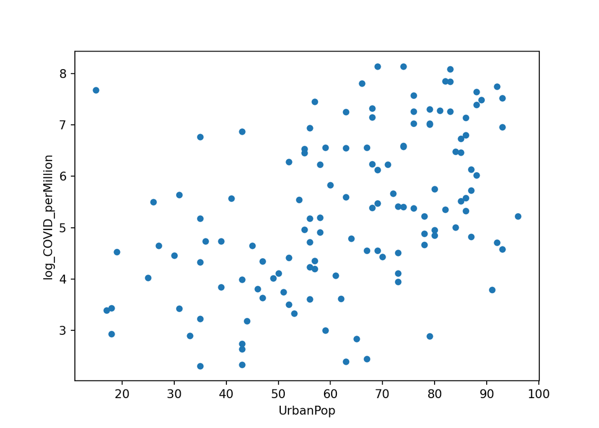

```python
corona_extended.plot.scatter(x="UrbanPop", y="log_COVID_perMillion")
```

Annyit lehet látni, hogy van egy ország, aminek hatalmas az egymillió főre jutó COVID esetszáma az elég alacsony, $20\%$ alatti városi népesség arányához képest. Jó lenne rájönni mi ez az ország!

Ehhez csináljunk egy olyan verziót az előző pontdiagramból, amin minden ponton szerepel, hogy az melyik országot jelöli.

Ennek elkészítéséhez felhasználunk egy `enumerate` névre hallgató függvényt. Ha ezt a függvényt ráeresztjük a **Country** oszlopra a data frame-ben, és az eredményt egy `for` ciklussal bejárjuk, akkor igazából két listát is bejárunk prhuzamosan:

- Egyet, ami az ország sorszámát mutatja a data frame-ben $0$-tól indexszelve. Ezt hívom én `sorszám`-nak.
- A másik listában pedig az országnevek vannak. Ez a kódban `szöveg`-nek becézem.

Fontos, hogy a két listát bejáró változó neve teljesen tetszőleges, akár “kismacska” és “gumimaci” is lehetnének. :)

```python
for sorszám, szöveg in enumerate(corona_extended.Country):
   print(sorszám)
   print(szöveg)
```

```
## 0
## Afghanistan
## 1
## Albania
## 2
## Algeria
## 3
## Antigua and Barbuda
## 4
## Argentina
## 5
## Armenia
## 6
## Australia
## 7
## Austria
## 8
## Azerbaijan
## 9
## Bahamas
```

És ez így folytatódik tovább a data frame összes sorára, csak most ide nem íratom ki a több mint 100 értéket. :)

Na, ezt az `enumerate`-t használó `for` ciklust úgy hasznosítjuk, hogy először egy külön `fig` című objektumba elmentjk az alap pontdiagramos ábrát, amit az előbb is megcsináltunk.  
Aztán elindítjuk ezt a `for` ciklust az `enumerate` alapján, és a cikluson belül használjuk a `fig` objektum `annotate` metódusát, ami a pontok feliratozását valósítja meg. A metódus paramétereiben megadom először, hogy az aktuális `szöveg`-et, azaz az országnevet rakja fel, mint felirat.  
A következő paraméter, ami zárójelben van az csak optikai tuning. Ott azt csinálom, hogy az $x,y$ koordinátáknak megfelelő oszlopok konkrét, pontdiagramon lévő koordinátáit kérdezem le az oszlopok `iat` tulajdonságában. Ez két lista, így mindig a *sorszámadik* elemét nézem a cikluson belül. Ezen koordináták közül a diagram $x$ tengelyét adó **UrbanPop**-ét eltolom $0.05$-tel. Így a pont felirata nem a pont középpontjában kezdődik, hanem attól $0.05$ egységgel jobbra. Így olvashatóbb lesz a cucc. :) Nyilván a felirat $y$ koordinátáját is tudnám itt szabályozni, és kedvem szerint fel-le rakni a felirat kezdőpontját, de erre itt nincs szükség, így az `annotate` paraméterben ezt a koordinátát csak csak változatlanul átadom.

Na, és lássuk is ezt a csodát működés közben! A kód végén egy `plt.show()` utasítással lehet a diagramot láthatóvá is tenni.

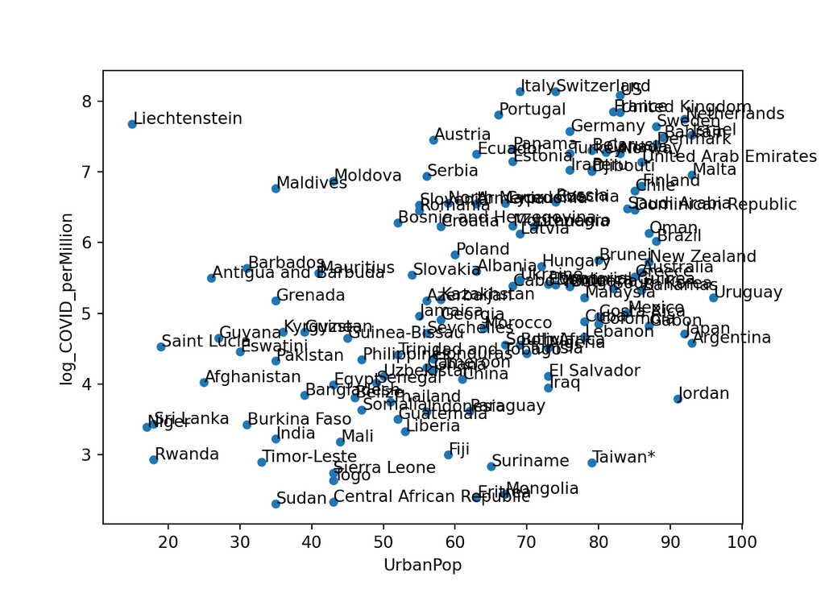

```python
fig = corona_extended.plot.scatter(x="UrbanPop", y="log_COVID_perMillion")

for sorszám, szöveg in enumerate(corona_extended.Country):
   fig.annotate(szöveg, (corona_extended.UrbanPop.iat[sorszám]+0.05, corona_extended.log_COVID_perMillion.iat[sorszám]))

plt.show()
```

E voilá: a gyanús kis államunk a magas esetszámával a kis városi népesség arány ellenére *Lichtenstein*! :) Érdekes észrevenni még, hogy pl. Taiwan elég jól áll: a városi népesség arányához képest elég alacsony az esetszáma! Magyarország, ha jól szemmelverjük, akkor látható, hogy gyakorlatilag pont a fő csapásirány közepén van kb: pont annyi nagyjából az esetszáma, amennyi a városi népesség aránya alapján “lennie kéne”. :)

## Gyakorló feladatok

1. Olvassuk be az index_2019_-_pour_import_1_1.csv nevű fájlt, és mentsük el a beolvasott adatokat egy **PressLiberty** nevű data frame-be!
   - Vigyázat! A fájlban tizedesvesszők vannak tizedes pont helyett! Használni kell a `read_csv` függvény `decimal` paraméterét! Meg kell a paraméterben adni, hogy a tizedeshelyeket a `','` karakter jelöli!
2. A **PressLiberty** data frame-ből csak az angol országnév (**EN_country**) és a 2019-es sajtószabadsági index (**Score 2019**) oszlopkra lesz szükségünk. A sajtószabadsági indexben az alacsonyabb érték jelent szabadabb sajtót egy országban. A többi változót töröljuk ki a data frame-ből!
3. A szűkített **PressLiberty** data frame oszlopainak neve legyen **Country** és **PressLiberty**!
4. Változtassuk meg az Egyesült Államok nevét “*United States*”-ről “*US*”-re a **PressLiberty** data frame-ben, hogy az összeköthető legyen a **corona_extended** data frame-el az országneveken keresztül!
5. Inner Join művelet segítségével vezessük át a sajtószabadsági index vonatkozó adatokat a **corona_extended** data frame-be!
6. Ábrázoljuk a **corona_extended** data frame-ben a kapcsolatot a **log_COVID_perMillion** és **PressLiberty** ismérvek között pontdiagramon! Értelmezze röviden szövegesen is a kapcsolatot! Logikus-e a kapcsolat iránya?
7. Vizsgáljuk meg a **PressLiberty** eloszlását hisztogramon!
8. Adjuk hozzá a **corona_extended** data frame-hez a **PressLiberty** logaritmusát **log_PressLiberty** néven!
9. Nézzük meg a korrelációs mátrixot a **log_COVID_perMillion**, **PressLiberty** és **log_PressLiberty** ismérvek között! Volt-e értelme a logaritmus alkalmazásának? Válaszát röviden indokolja!
10. Ábrázoljuk a **corona_extended** data frame-ben a kapcsolatot a **COVID_perMillion** logaritmusa és a **PressLiberty** logaritmusa között pontdiagramon! Az egyes pontokon szerepeljen az országok neve is!
    - Van-e olyan ország, amelyik a két ismérv kapcsolatát leíró általános tendenciához képest eltérően viselkedik? Válaszát röviden indokolja!

## Gyakorló feladatok megoldása

### 1. feladat

```python
PressLiberty = pd.read_csv('index_2019_-_pour_import_1_1.csv', decimal=',')
PressLiberty.info()
```

```
## <class 'pandas.core.frame.DataFrame'>
## RangeIndex: 180 entries, 0 to 179
## Data columns (total 14 columns):
##  #   Column            Non-Null Count  Dtype
## ---  ------            --------------  -----
##  0   ISO               180 non-null    object
##  1   Rank2019          180 non-null    int64
##  2   FR_Country        180 non-null    object
##  3   EN_country        180 non-null    object
##  4   ES_country        180 non-null    object
##  5   Score A           180 non-null    float64
##  6   Sco Exa           180 non-null    float64
##  7   Score 2019        180 non-null    float64
##  8   Progression RANK  180 non-null    int64
##  9   Rank 2018         180 non-null    int64
##  10  Score 2018        180 non-null    float64
##  11  Zone              180 non-null    object
##  12  AR_country        180 non-null    object
##  13  FA_country        180 non-null    object
## dtypes: float64(4), int64(3), object(7)
## memory usage: 19.8+ KB
```

### 2. feladat

```python
PressLiberty = PressLiberty.loc[:,['EN_country', 'Score 2019']]
PressLiberty.info()
```

```
## <class 'pandas.core.frame.DataFrame'>
## RangeIndex: 180 entries, 0 to 179
## Data columns (total 2 columns):
##  #   Column      Non-Null Count  Dtype
## ---  ------      --------------  -----
##  0   EN_country  180 non-null    object
##  1   Score 2019  180 non-null    float64
## dtypes: float64(1), object(1)
## memory usage: 2.9+ KB
```

### 3. feladat

```python
PressLiberty.columns = ['Country', 'PressLiberty']
PressLiberty.info()
```

```
## <class 'pandas.core.frame.DataFrame'>
## RangeIndex: 180 entries, 0 to 179
## Data columns (total 2 columns):
##  #   Column        Non-Null Count  Dtype
## ---  ------        --------------  -----
##  0   Country       180 non-null    object
##  1   PressLiberty  180 non-null    float64
## dtypes: float64(1), object(1)
## memory usage: 2.9+ KB
```

### 4. feladat

```python
PressLiberty['Country'] = PressLiberty['Country'].replace('United States', 'US')
```

### 5. feladat

```python
corona_extended = pd.merge(corona_extended, PressLiberty, how='inner', on='Country')
corona_extended.info()
```

```
## <class 'pandas.core.frame.DataFrame'>
## Int64Index: 115 entries, 0 to 114
## Data columns (total 8 columns):
##  #   Column                Non-Null Count  Dtype
## ---  ------                --------------  -----
##  0   Country               115 non-null    object
##  1   COVID_Cases           115 non-null    int64
##  2   Pop                   115 non-null    int64
##  3   PopDensity            115 non-null    int64
##  4   UrbanPop              115 non-null    int32
##  5   COVID_perMillion      115 non-null    float64
##  6   log_COVID_perMillion  115 non-null    float64
##  7   PressLiberty          115 non-null    float64
## dtypes: float64(3), int32(1), int64(3), object(1)
## memory usage: 7.6+ KB
```

### 6. feladat

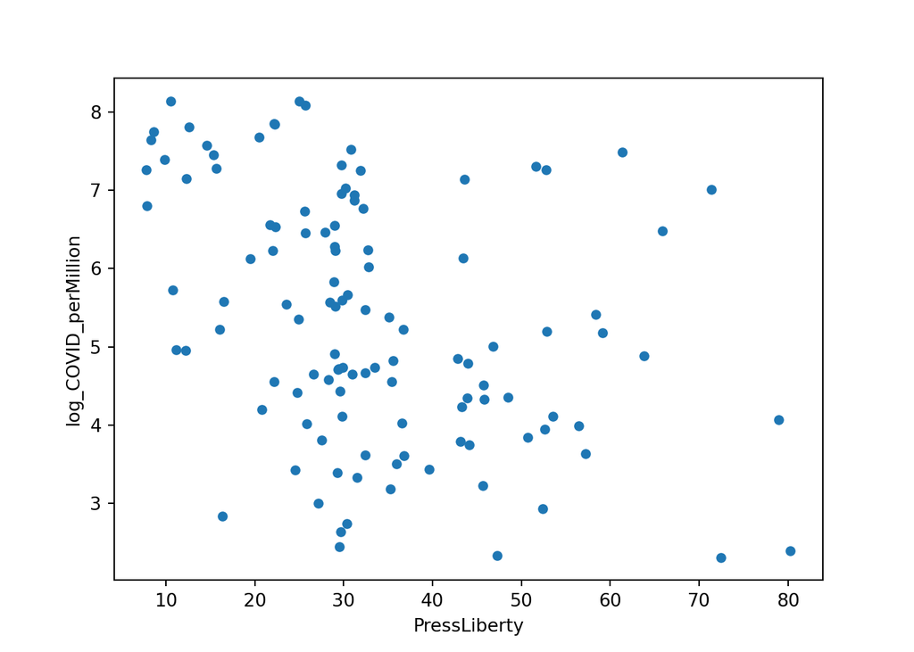

```python
corona_extended.plot.scatter(x="PressLiberty", y="log_COVID_perMillion")
```

Úgy látszik, hogy a a kapcsolat ellentétes irányú: a sajtószabadsági index növekedésével jellemzően csökken az esetszám. Mivel a magasabb index jelenti a kevésbé szabad sajtót, így első olvasatra nem logikus a kapcsolat iránya: kevésbé szabad sajtóval rendelkező országokban kevesebb az esetszám egymillió főre nézve. De egy picit belegondolva lehet logikus a dolog: a szabadabb sajtóval rendelkező országok jellemzően gazdagabb országok is. Feltehetően ilyen országokban a COVID tesztelésre is több erőforrás jut.

### 7. feladat

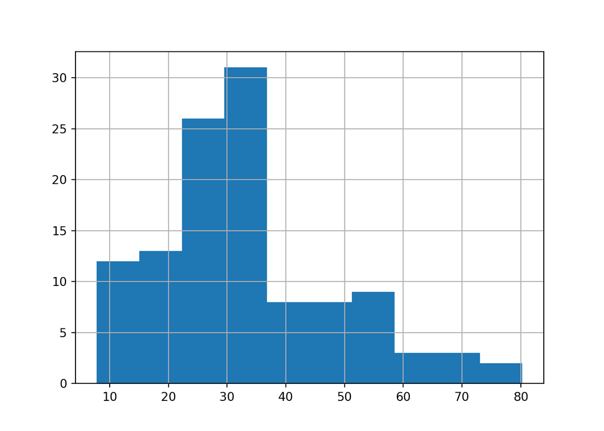

```python
corona_extended.PressLiberty.hist()
```

Az eloszlás némileg jobbra elnyúló, vannak felső irányban kiugró értékek. Érdemes lehet logaritmust alkalmazni az oszlopon.

### 8. feladat

```python
corona_extended['log_PressLiberty'] = np.log(corona_extended['PressLiberty'])
corona_extended.info()
```

```
## <class 'pandas.core.frame.DataFrame'>
## Int64Index: 115 entries, 0 to 114
## Data columns (total 9 columns):
##  #   Column                Non-Null Count  Dtype
## ---  ------                --------------  -----
##  0   Country               115 non-null    object
##  1   COVID_Cases           115 non-null    int64
##  2   Pop                   115 non-null    int64
##  3   PopDensity            115 non-null    int64
##  4   UrbanPop              115 non-null    int32
##  5   COVID_perMillion      115 non-null    float64
##  6   log_COVID_perMillion  115 non-null    float64
##  7   PressLiberty          115 non-null    float64
##  8   log_PressLiberty      115 non-null    float64
## dtypes: float64(4), int32(1), int64(3), object(1)
## memory usage: 8.5+ KB
```

### 9. feladat

```python
corona_extended.loc[:,['log_COVID_perMillion', 'PressLiberty', 'log_PressLiberty']].corr()
```

```
##                       log_COVID_perMillion  PressLiberty  log_PressLiberty
## log_COVID_perMillion              1.000000     -0.381829         -0.430291
## PressLiberty                     -0.381829      1.000000          0.944278
## log_PressLiberty                 -0.430291      0.944278          1.000000
```

Volt értelme, a sajtószabadsági indexnek jobbra elnyúló az eloszlása, így a kilógó értékek hatását az egymillió főre vetített esetszámmal vett kapcsolatára tudta mérsékelni a logaritmus. Ez onnan látszódik, hogy a korreláció abszolút értékben $0.05$ egységgel nőtt. Nem akkora a javulás, mint a városi népesség arányával vett korrelációnál tapasztaltuk, de azért észrevehető.

### 10. feladat

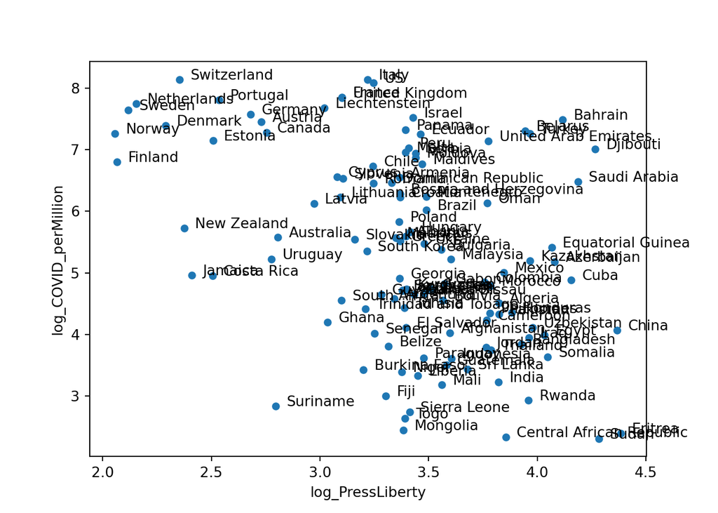

```python
fig = corona_extended.plot.scatter(x="log_PressLiberty", y="log_COVID_perMillion")

for sorszám, szöveg in enumerate(corona_extended.Country):
   fig.annotate(szöveg, (corona_extended.log_PressLiberty.iat[sorszám]+0.05, corona_extended.log_COVID_perMillion.iat[sorszám]))

plt.show()
```